# ReisSense: Train Occupancy Prediction

Anushka Samant, Delfina Vildosola

2023-11-22

```r
knitr::opts_chunk$set(echo = TRUE, include = TRUE, warning = FALSE, message = FALSE, fig.align = 'left', cache = TRUE)

require(foreign)
require(nnet)
require(ggplot2)
require(reshape2)
library(lubridate)
library(dplyr)
library(sf)
library(tidyverse)
library(tidyr)
library(ggmap)
library(stplanr)
library(tmap)
library(caret)
library(stringr)
library(viridis)
require(gridExtra)
library(kableExtra)
library(forestmangr)
library(MASS)
library(ggiraph)
library(grid)

register_stadiamaps("7a232571-423d-4c0b-a964-bad5e32ecbb6", write = TRUE)

options(scipen=99)

Theme1 <- theme(legend.box = "horizontal",
        plot.title = element_text(size=12),
        plot.subtitle = element_text(size=8),
        axis.title.x = element_text(size = 4))
Theme2 <- theme(plot.title = element_text(size=12),
                plot.subtitle = element_text(size=9))

palette3 <- c("#fcfdbf","#b73779","#2c115f")
palette3b <- c("#fcfdbf","#feb078","#b73779")
palette3c <- c("#feb078","#b73779","#2c115f")
palette4 <- c("#fcfdbf","#f1605d","#721f81","#2c115f")
palette4b <- c("#fcfdbf","#feb078","#f1605d","#b73779")
palette5 <- c("#fcfdbf","#feb078","#b73779","#51127c","#2c115f")
palette5b <- c("#feb078","#f1605d","#b73779","#51127c","#2c115f")

mapTheme <- theme(plot.title =element_text(size=12),
                  plot.subtitle = element_text(size=8),
                  plot.caption = element_text(size = 6),
                  axis.line=element_blank(),
                  axis.text.x=element_blank(),
                  axis.text.y=element_blank(),
                  axis.ticks=element_blank(),
                  axis.title.x=element_blank(),
                  axis.title.y=element_blank(),
                  panel.background=element_blank(),
                  panel.border=element_blank(),
                  panel.grid.major=element_line(colour = 'transparent'),
                  panel.grid.minor=element_blank(),
                  legend.direction = "vertical",
                  legend.position = "right",
                  plot.margin = margin(1, 1, 1, 1, 'cm'),
                  legend.key.height = unit(1, "cm"), legend.key.width = unit(0.2, "cm"))

plotTheme <- theme(
  plot.title =element_text(size=12),
  plot.subtitle = element_text(size=8),
  plot.caption = element_text(size = 6),
  axis.text.x = element_text(size = 10, angle = 45, hjust = 1),
  axis.text.y = element_text(size = 10),
  axis.title.y = element_text(size = 10),
  panel.background=element_blank(),
  plot.background=element_blank(),
  panel.grid.major=element_line(colour="#D0D0D0",size=.2),
  axis.ticks=element_blank())


substrRight <- function(x, n){
  substr(x, nchar(x)-n+1, nchar(x))}

options(scipen=50, digits=10)

nn_function <- function(measureFrom,measureTo,k) {

  nn <-
    FNN::get.knnx(measureTo, measureFrom, k)$nn.dist

  output <-
    as.data.frame(nn) %>%
    rownames_to_column(var = "thisPoint") %>%
    gather(points, point_distance, V1:ncol(.)) %>%
    arrange(as.numeric(thisPoint)) %>%
    group_by(thisPoint) %>%
    summarize(pointDistance = mean(point_distance)) %>%
    arrange(as.numeric(thisPoint)) %>%
    dplyr::select(-thisPoint)

  return(output)
}

Modes <- function(x) {
  ux <- unique(x)
  tab <- tabulate(match(x, ux))
  ux[tab == max(tab)]
}

### DATA - Delfina

# setwd("C:/Users/dmvil/Desktop/PPA/final_project/")
#
# stations <- read.csv("C:/Users/dmvil/Desktop/PPA/final_project/data/stations.csv")%>%
# st_as_sf(coords = c("longitude", "latitude"), crs = 4326) %>%
# mutate(station_id = as.numeric(str_sub(URI, 31, 39)))%>%
#   dplyr::select(-alternative.fr,-alternative.nl,-alternative.de, -alternative.en, -country.code, -URI)
#
# rail <- st_read("C:/Users/dmvil/Desktop/PPA/final_project/data/lijnsecties.geojson")%>%
#   dplyr::select(-ecs_voltfreq, -mfrom, -mto, -ecs_maxtraincurrent, -ecs_maxstandstillcurrent, -ecs_minwireheight,)
#
# rail2 <- st_read("C:/Users/dmvil/Desktop/PPA/final_project/data/belgium-railways-shape/railways.shp")%>%
#   filter(type=="rail")
#
# railways <- st_read("C:/Users/dmvil/Desktop/PPA/final_project/data/railway_lines_opendata/hotosm_bel_railways_lines.shp")%>%
#   st_as_sf(coords = c("longitude", "latitude"), crs = 4326)
#
# line <- st_read("https://raw.githubusercontent.com/GillesVandewiele/KaggleTrainOccupancy/master/line_info.csv")
# belgium <- st_read("C:/Users/dmvil/Desktop/PPA/final_project/data/belgium.geojson.json")
#
# population <- st_read("C:/Users/dmvil/Desktop/PPA/final_project/data/population.geojson")
#
# punctual <- read.csv("C:/Users/dmvil/Desktop/PPA/final_project/data/2016-delays.csv")
# crossing <- st_read("C:/Users/dmvil/Desktop/PPA/final_project/data/level-cross.geojson")

### DATA - Anushka

setwd("D:/OneDrive - PennO365/Semester 3/PPA/PPA Final/Final Project")

stations <- read.csv("D:/OneDrive - PennO365/Semester 3/PPA/PPA Final/Final Project/data/stations.csv")%>%
st_as_sf(coords = c("longitude", "latitude"), crs = 4326) %>%
mutate(station_id = as.numeric(str_sub(URI, 31, 39)))%>%
  dplyr::select(-alternative.fr,-alternative.nl,-alternative.de, -alternative.en, -country.code, -URI)

rail <- st_read("D:/OneDrive - PennO365/Semester 3/PPA/PPA Final/Final Project/data/lijnsecties.geojson")%>%
  dplyr::select(-ecs_voltfreq, -mfrom, -mto, -ecs_maxtraincurrent, -ecs_maxstandstillcurrent, -ecs_minwireheight,)

rail2 <- st_read("D:/OneDrive - PennO365/Semester 3/PPA/PPA Final/Final Project/data/belgium-railways-shape/railways.shp")%>%
  filter(type=="rail")

railways <- st_read("D:/OneDrive - PennO365/Semester 3/PPA/PPA Final/Final Project/data/railway_lines_opendata/hotosm_bel_railways_lines.shp")%>%
st_as_sf(coords = c("longitude", "latitude"), crs = 4326)

line <- st_read("D:/OneDrive - PennO365/Semester 3/PPA/PPA Final/Final Project/data/line_info.csv")

belgium <- st_read("D:/OneDrive - PennO365/Semester 3/PPA/PPA Final/Final Project/data/belgium.geojson.json")

population <- st_read("D:/OneDrive - PennO365/Semester 3/PPA/PPA Final/Final Project/data/population.geojson")

punctual <- read.csv("D:/OneDrive - PennO365/Semester 3/PPA/PPA Final/Final Project/data/2016-delays.csv")

crossing <- st_read("D:/OneDrive - PennO365/Semester 3/PPA/PPA Final/Final Project/data/level-cross.geojson")

# belgium_satmap <- get_stadiamap(bbox = c(left = 2.739258, bottom = 49.563228,
#                                           right = 6.551513, top = 51.695260), zoom = 11)
#
# stations$lon <- as.numeric(stations$lon)
# stations$lat <- as.numeric(stations$lat)
# ggmap(belgium_satmap)+geom_point(aes(x = lon, y = lat), data = stations, size = 3)
```

# Introduction

Belgium’s rail network, largely developed in the XIXth century, is one of the densest in the world. It is a central element of the Belgian mobility menu and the government plays an important role in promoting the use through a variety of policies and subsidies. Students and elderly citizens are encouraged to travel in off-peak times and public employees benefit from free or subsidized travel, and demand is high for this critical service in the densely populated European country. In recent years there’s been mounting concern about the state of infrastructure and the safety and reliability of the network. Public subsidies mean there is significant pressure to ensure the efficient use of funds and provision of reliable, safe, comfortable services to the users. As a result, this old network has substantial maintenance needs.

## Use Case

We propose an occupancy prediction model that feeds a tool or application to assist operators and transportation planners in better planning the system maintenance operations, taking into account the forecasted occupancy levels. This app would aid in minimizing the amount and impact of necessary planned service restrictions and have additional value as a means of effective communication around planned maintenance. By integrating and processing information and showing it in a clear centralized manner, our app will provide clarity to operational staff who need to make important decisions on a daily basis.

The occupancy forecasting system can play a crucial role, allowing the National Railway Company of Belgium (NMBS/SNCB) and planning authorities to optimize scheduling around peak demand. This would improve service safety and reliability while improving operational and financial performance.

## Objectives

Objectives include optimizing maintenance, lowering costs (in terms of lost revenue) and minimizing maintenance-related disruptions to improve operations and user experience. By optimizing maintenance schedules, the operator can reduce costs while improving passengers’ experience and satisfaction. Broader subsequent goals for this project include revenue-maximizing train schedules.

# Methodology

Exploratory analysis of the spatial and temporal data (geographic and temporal distribution of infrastructure, demand, weather and population), to identify patterns and relationships among variables.

The Belgian system can be considered a multinodal network, with some stations concentrating higher proportions of trips. Greater station density and a higher number of possible connections were more clearly correlated to trip count and occupancy than population density.

Time series analysis revealed some unexpected fluctuations in occupancy and trip counts across the week, such as many low occupancy trips on Friday afternoons. Our engineered features also showed higher numbers of low occupancy trips during rush hour.

The Belgian system is a multinodal network, but some stations concentrate higher proportions of trips.

Higher station density and possible connections correlate more clearly to trip count and occupancy than population density. Time series analysis revealed some unexpected fluctuations in occupancy and trip counts across the week, such as many low occupancy trips on Friday afternoons. Our engineered features also showed higher numbers of low occupancy trips during rush hour.

## Data

This analysis uses the [Kaggle datasets](http://www.kaggle.com/c/train-occupancy-prediction/data) of train lines, schedules and their occupancy levels, and stations. There’s three possible levels of train occupancy (dependent variable): **low, medium, and high**.

We are also using:

- Belgian weather data
- Belgian census data
- Punctuality data
- Level crossings data

### Train Data

```r
#rm(trains)
# Read the 'trains_train.csv' file and perform data manipulation using the dplyr and sf packages
trains <- read.csv("D:/OneDrive - PennO365/Semester 3/PPA/PPA Final/Final Project/data/trains_train.csv") %>%
#trains <- read.csv("C:/Users/dmvil/Desktop/PPA/final_project/data/trains_train.csv") %>%
  mutate(from = as.numeric(as.character(from)),
         to = as.numeric(as.character(to)))



#trains[is.na(trains)] <- 0

trains <- trains %>%
  left_join(dplyr::select(stations, station_id, avg_stop_times, name), by = c("from" = "station_id")) %>%
  st_sf() %>%
  mutate(from.X = st_coordinates(.)[, 1],
         from.Y = st_coordinates(.)[, 2]) %>%
  st_drop_geometry() %>%
  left_join(dplyr::select(stations, station_id, avg_stop_times), by = c("to" = "station_id")) %>%
  st_sf() %>%
  mutate(to.X = st_coordinates(.)[, 1],
         to.Y = st_coordinates(.)[, 2]) %>%
  st_drop_geometry() %>%
  mutate(distance = sqrt((from.X - to.X)^2 + (from.Y - to.Y)^2),
         stop_times_from = avg_stop_times.x,
         stop_times_to = avg_stop_times.y) %>%
  dplyr::select(-avg_stop_times.x, -avg_stop_times.y) %>%
  arrange(-distance)  # Arrange the data by descending distance

# Modify factors and create new variables in the 'trains' dataset
trains$occupancy <- factor(trains$occupancy)
trains$occ2 <- relevel(trains$occupancy, ref = "low")  # Relevel the 'occ2' variable
trains$OD <- paste(trains$from, trains$to, sep = "-")  # Create a new variable 'OD' by concatenating 'from' and 'to'

trains$time <- parse_date_time(trains$time, '%I:%M:%S %p')  # Parse the 'time' variable as a date-time object
trains$time <- substr(trains$time, 12, 19)  # Extract the time component from the date-time object
trains$date_time <- as.POSIXct(paste(trains$date, trains$time), format = "%Y-%m-%d %H:%M:%S")  # Combine date and time into a new variable 'date_time'

# Further data manipulation and create new variables
trains <-
  trains %>%
  mutate(veh = substr(vehicle, 1, 1),
         interval60 = floor_date(ymd_hms(date_time), unit = "hour"),
         interval15 = floor_date(ymd_hms(date_time), unit = "15 mins"),
         week = week(interval60),
         dotw = wday(interval60, label = TRUE),
         veh = substr(vehicle, 1, 1),
         hour = as.numeric(substr(time, 1, 2)),
         weekend = ifelse(dotw == "Sat" | dotw == "Sun", 1, 0),
         mor.jam = ifelse(hour >= 6 & hour <= 10 & weekend == "0", 1, 0),
         eve.jam = ifelse(hour >= 15 & hour <= 19 & weekend == "0", 1, 0),
         hour = factor(hour),
         weekend = factor(weekend),
         from = factor(from),
         to = factor(to))
```

#### Table of Trip Data

Below is a sample of the trip data used, showing key variables like date, time, occupancy, origin and destination.

```r
# Display a table of Trip Data (using the 'kable' function from the 'knitr' package) of the first 15 rows of the cleaned data
kable(trains[1:20,], caption = "2016 SNBC Trip Data") %>%
  kable_styling("striped", full_width = F) %>%
  kable_styling() %>%
  scroll_box(width = "750px", height = "500px")  # Display the table in a scrollable box
```

2016 SNBC Trip Data

| date | time | connection | from | to | vehicle | occupancy | name | from.X | from.Y | to.X | to.Y | distance | stop_times_from | stop_times_to | occ2 | OD | date_time | veh | interval60 | interval15 | week | dotw | hour | weekend | mor.jam | eve.jam |
| --- | --- | --- | --- | --- | --- | --- | --- | --- | --- | --- | --- | --- | --- | --- | --- | --- | --- | --- | --- | --- | --- | --- | --- | --- | --- | --- |
| 2016-08-02 | 10:44:44 | 8814001/20160802/TGV9826 | 8814001 | 8731901 | TGV9826 | medium | Brussel-Zuid/Bruxelles-Midi | 4.336531 | 50.835707 | 5.3172430 | 43.4551280 | 7.445451121 | 686.61560694 | 3.971098266 | medium | 8814001-8731901 | 2016-08-02 10:44:44 | T | 2016-08-02 10:00:00 | 2016-08-02 10:30:00 | 31 | Tue | 10 | 0 | 1 | 0 |
| 2016-10-15 | 20:11:53 | 008844628/20161015/IC533 | 8844628 | 8891702 | IC533 | low | Eupen | 6.037110 | 50.635157 | 2.9258090 | 51.2282120 | 3.167318763 | 18.21676301 | 59.895953757 | low | 8844628-8891702 | 2016-10-15 20:11:53 | I | 2016-10-15 20:00:00 | 2016-10-15 20:00:00 | 42 | Sat | 20 | 1 | 0 | 0 |
| 2016-10-07 | 17:31:27 | 008814001/20161007/THA9360 | 8814001 | 8727100 | THA9360 | medium | Brussel-Zuid/Bruxelles-Midi | 4.336531 | 50.835707 | 2.3553093 | 48.8809984 | 2.783186148 | 686.61560694 | 27.994219653 | medium | 8814001-8727100 | 2016-10-07 17:31:27 | T | 2016-10-07 17:00:00 | 2016-10-07 17:30:00 | 41 | Fri | 17 | 0 | 0 | 1 |
| 2016-10-18 | 20:14:07 | 008814001/20161018/THA9388 | 8814001 | 8727100 | THA9388 | high | Brussel-Zuid/Bruxelles-Midi | 4.336531 | 50.835707 | 2.3553093 | 48.8809984 | 2.783186148 | 686.61560694 | 27.994219653 | high | 8814001-8727100 | 2016-10-18 20:14:07 | T | 2016-10-18 20:00:00 | 2016-10-18 20:00:00 | 42 | Tue | 20 | 0 | 0 | 0 |
| 2016-09-27 | 12:40:58 | 008841004/20160927/IC535 | 8841004 | 8891702 | IC535 | medium | Liège-Guillemins | 5.566695 | 50.624550 | 2.9258090 | 51.2282120 | 2.709001048 | 269.12427746 | 59.895953757 | medium | 8841004-8891702 | 2016-09-27 12:40:58 | I | 2016-09-27 12:00:00 | 2016-09-27 12:30:00 | 39 | Tue | 12 | 0 | 0 | 0 |
| 2016-09-23 | 20:06:13 | 008814001/20160924/THA9437 | 8814001 | 8015458 | THA9437 | low | Brussel-Zuid/Bruxelles-Midi | 4.336531 | 50.835707 | 6.9588230 | 50.9427210 | 2.624474677 | 686.61560694 | 12.540462428 | low | 8814001-8015458 | 2016-09-23 20:06:13 | T | 2016-09-23 20:00:00 | 2016-09-23 20:00:00 | 39 | Fri | 20 | 0 | 0 | 0 |
| 2016-08-10 | 08:53:55 | 8200518/20160810/L2579 | 8200518 | 8821006 | L2579 | low | Capellen | 5.982265 | 49.638463 | 4.4211010 | 51.2172000 | 2.220280061 | 26.22254335 | 467.982658959 | low | 8200518-8821006 | 2016-08-10 08:53:55 | L | 2016-08-10 08:00:00 | 2016-08-10 08:45:00 | 32 | Wed | 8 | 0 | 1 | 0 |
| 2016-10-06 | 22:35:02 | 008814001/20161006/IC2108 | 8814001 | 8200100 | IC2108 | high | Brussel-Zuid/Bruxelles-Midi | 4.336531 | 50.835707 | 6.1333310 | 49.5999960 | 2.180704454 | 686.61560694 | 146.601156069 | high | 8814001-8200100 | 2016-10-06 22:35:02 | I | 2016-10-06 22:00:00 | 2016-10-06 22:30:00 | 40 | Thu | 22 | 0 | 0 | 0 |
| 2016-10-07 | 10:25:22 | 008814001/20161007/IC2108 | 8814001 | 8200100 | IC2108 | low | Brussel-Zuid/Bruxelles-Midi | 4.336531 | 50.835707 | 6.1333310 | 49.5999960 | 2.180704454 | 686.61560694 | 146.601156069 | low | 8814001-8200100 | 2016-10-07 10:25:22 | I | 2016-10-07 10:00:00 | 2016-10-07 10:15:00 | 41 | Fri | 10 | 0 | 1 | 0 |
| 2016-10-09 | 23:26:29 | 008814001/20161009/IC2105 | 8814001 | 8200100 | IC2105 | low | Brussel-Zuid/Bruxelles-Midi | 4.336531 | 50.835707 | 6.1333310 | 49.5999960 | 2.180704454 | 686.61560694 | 146.601156069 | low | 8814001-8200100 | 2016-10-09 23:26:29 | I | 2016-10-09 23:00:00 | 2016-10-09 23:15:00 | 41 | Sun | 23 | 1 | 0 | 0 |
| 2016-10-09 | 23:27:10 | 008200100/20161009/IC2128 | 8200100 | 8814001 | IC2128 | low | Lëtzebuerg | 6.133331 | 49.599996 | 4.3365310 | 50.8357070 | 2.180704454 | 146.60115607 | 686.615606936 | low | 8200100-8814001 | 2016-10-09 23:27:10 | I | 2016-10-09 23:00:00 | 2016-10-09 23:15:00 | 41 | Sun | 23 | 1 | 0 | 0 |
| 2016-10-20 | 08:52:21 | 008831807/20161020/IC1534 | 8831807 | 8891009 | IC1534 | medium | Sint-Truiden | 5.176654 | 50.817620 | 3.2167260 | 51.1972260 | 1.996351292 | 37.95375723 | 164.419075144 | medium | 8831807-8891009 | 2016-10-20 08:52:21 | I | 2016-10-20 08:00:00 | 2016-10-20 08:45:00 | 42 | Thu | 8 | 0 | 1 | 0 |
| 2016-09-25 | 17:15:16 | 008892007/20160925/IC516 | 8892007 | 8841004 | IC516 | medium | Gent-Sint-Pieters | 3.710675 | 51.035896 | 5.5666950 | 50.6245500 | 1.901056488 | 309.01445087 | 269.124277457 | medium | 8892007-8841004 | 2016-09-25 17:15:16 | I | 2016-09-25 17:00:00 | 2016-09-25 17:15:00 | 39 | Sun | 17 | 1 | 0 | 0 |
| 2016-10-04 | 15:40:04 | 008841004/20161004/IC437 | 8841004 | 8892007 | IC437 | low | Liège-Guillemins | 5.566695 | 50.624550 | 3.7106750 | 51.0358960 | 1.901056488 | 269.12427746 | 309.014450867 | low | 8841004-8892007 | 2016-10-04 15:40:04 | I | 2016-10-04 15:00:00 | 2016-10-04 15:30:00 | 40 | Tue | 15 | 0 | 0 | 1 |
| 2016-10-28 | 13:44:44 | 8891009/20161028/IC1813 | 8891009 | 8832409 | IC1813 | medium | Brugge | 3.216726 | 51.197226 | 5.1163360 | 51.1910500 | 1.899620040 | 164.41907514 | 59.751445087 | medium | 8891009-8832409 | 2016-10-28 13:44:44 | I | 2016-10-28 13:00:00 | 2016-10-28 13:30:00 | 44 | Fri | 13 | 0 | 0 | 0 |
| 2016-09-17 | 09:29:47 | 008814001/20160917/IC2109 | 8814001 | 8866001 | IC2109 | low | Brussel-Zuid/Bruxelles-Midi | 4.336531 | 50.835707 | 5.8099710 | 49.6805300 | 1.872287194 | 686.61560694 | 85.713872832 | low | 8814001-8866001 | 2016-09-17 09:29:47 | I | 2016-09-17 09:00:00 | 2016-09-17 09:15:00 | 38 | Sat | 9 | 1 | 0 | 0 |
| 2016-10-08 | 23:56:35 | 008866001/20161008/IC2140 | 8866001 | 8811304 | IC2140 | high | Arlon | 5.809971 | 49.680530 | 4.3736740 | 50.8389430 | 1.845228915 | 85.71387283 | 142.601156069 | high | 8866001-8811304 | 2016-10-08 23:56:35 | I | 2016-10-08 23:00:00 | 2016-10-08 23:45:00 | 41 | Sat | 23 | 1 | 0 | 0 |
| 2016-10-08 | 23:56:43 | 008866001/20161008/IC2141 | 8866001 | 8811304 | IC2141 | high | Arlon | 5.809971 | 49.680530 | 4.3736740 | 50.8389430 | 1.845228915 | 85.71387283 | 142.601156069 | high | 8866001-8811304 | 2016-10-08 23:56:43 | I | 2016-10-08 23:00:00 | 2016-10-08 23:45:00 | 41 | Sat | 23 | 1 | 0 | 0 |
| 2016-09-18 | 18:50:37 | 008891702/20160918/IC518 | 8891702 | 8833001 | IC518 | high | Oostende | 2.925809 | 51.228212 | 4.7158660 | 50.8822800 | 1.823176627 | 59.89595376 | 351.916184971 | high | 8891702-8833001 | 2016-09-18 18:50:37 | I | 2016-09-18 18:00:00 | 2016-09-18 18:45:00 | 38 | Sun | 18 | 1 | 0 | 0 |
| 2016-10-09 | 14:52:38 | 008833001/20161009/IC537 | 8833001 | 8891702 | IC537 | low | Leuven | 4.715866 | 50.882280 | 2.9258090 | 51.2282120 | 1.823176627 | 351.91618497 | 59.895953757 | low | 8833001-8891702 | 2016-10-09 14:52:38 | I | 2016-10-09 14:00:00 | 2016-10-09 14:45:00 | 41 | Sun | 14 | 1 | 0 | 0 |

```r
# stplanr facilitates the connection of "from" and "to" data, transforming it into "line" data, as illustrated in the table.
#rm(new_train)

new_train <- trains%>%
  mutate(new = 1)%>%
  dplyr::select(OD, new)%>%
  group_by(OD) %>%
  summarise( count = sum (new))

new_train <- separate(new_train,OD,into=c("from","to"), sep="-")
new_train <- subset(new_train, new_train$to!="1000000" & new_train$from!="1000000" & new_train$to!="0" & !is.na(new_train$to) & !is.na(new_train$from) & new_train$to!="NA" & new_train$from!="NA")

new_train <- subset(new_train, new_train$to!=new_train$from)
new_train$from <- as.numeric(as.character(new_train$from))
new_train$to <- as.numeric(new_train$to)

station_extract <- stations%>%
  mutate(to = station_id)%>%
  dplyr::select(to)

z <- station_extract
l <- od2line(flow = new_train, zones = z)
#write.csv(l, file="D:/OneDrive - PennO365/Semester 3/PPA/PPA Final/Final Project/data/l-export.csv")

l$OD <-  paste (l$from, l$to, sep= "-")
OD_Pair <- merge(l,trains, by = "OD", all.x=T, all.y=F)

train_sf <- merge(l[,c("geometry","OD")], trains, by = "OD", alll=T)
```

#### Plots of rail lines, stations, crossings, and OD pairs

One of the first steps is to plot the basic elements of the network: stations and rail lines. We also convert the train data generating Origin-Destination (O-D) pairings using the `stplanr` package. the plot below shows the pairings and their occupancy categories. This steps help us have our first visual understanding of the spatial layout of the system and the functional relationship between the nodes.

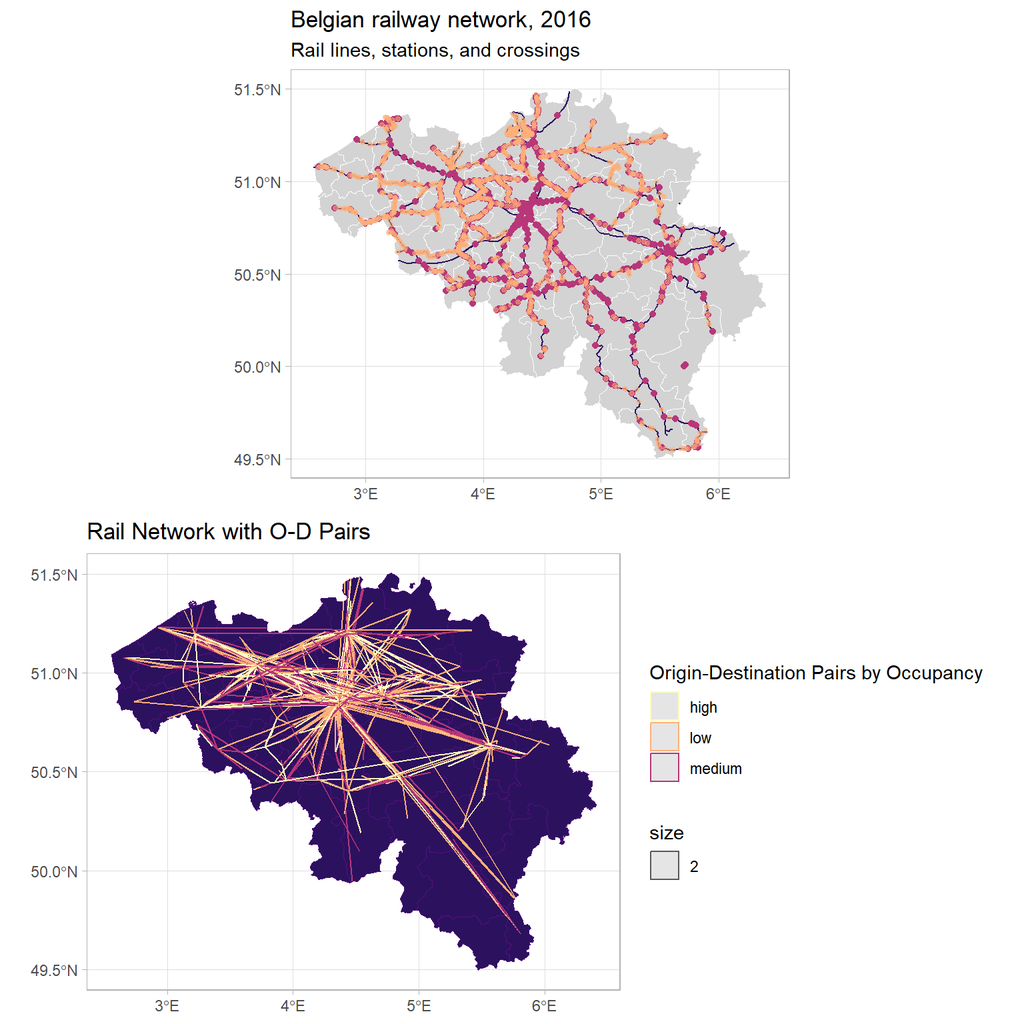

```r
stations_belg_only <- st_intersection(stations, belgium)

# plot1 <- ggplot(OD_Pair) +
#   geom_sf(data = belgium, fill = "lightgray", color = "white") +
#   geom_sf(data=rail, inherit.aes = FALSE,na.rm=T, col="#2c115f", lwd=0.5, show.legend = "rail")+
#   geom_sf(data = stations_belg_only, size = 1.5, inherit.aes = FALSE, color = "#b73779", show.legend = "stations") +
#   geom_sf(data = crossing, size = 1, inherit.aes = FALSE, color = "#feb078", alpha = 0.5, show.legend = "crossings") +
#   ylim(min(49.5), max(51.5)) +
#   xlim(min(2.5), max(6.3)) +
#   labs(
#     title = "Belgian railway network, 2016",
#     subtitle = "Rail lines, stations and crossings")
#   theme_light()
# print(plot1)

#rm(stations_belg_only)
#ggsave("plot1.png", plot = plot1, width = 8, height = 6, dpi = 300, bg = "transparent")

OD_Pair_filtered <- st_intersection(OD_Pair, belgium)

# ggplot(OD_Pair) +
#   geom_sf(data = belgium, fill = "#2c115f", color = "#51127c") +
#   geom_sf(data = OD_Pair_filtered, aes(color = occupancy, size = 2), inherit.aes = FALSE) +
#   ylim(min(49.5), max(51.5)) +
#   xlim(min(2.5), max(6.3)) +
#   scale_color_manual(values = palette3b) +
#   theme_light() +
#   guides(color = guide_legend(title = "Origin-Destination Pairs by Occupancy",
#                               override.aes = list(color = c(high = "#fcfdbf", medium = "#feb078", low = "#b73779"))))
#
# combined_plot <- grid.arrange(plot1, plot2, ncol = 1)
# print(combined_plot)

library(gridExtra)

grid.arrange(
  ggplot(OD_Pair) +
    geom_sf(data = belgium, fill = "lightgray", color = "white") +
    geom_sf(data = rail, inherit.aes = FALSE, na.rm = TRUE, col = "#2c115f", lwd = 0.5) +
    geom_sf(data = stations_belg_only, size = 1.5, inherit.aes = FALSE, color = "#b73779") +
    geom_sf(data = crossing, size = 1, inherit.aes = FALSE, color = "#feb078", alpha = 0.5) +
    # ylim(min(49.5), max(51.5)) +
    # xlim(min(2.5), max(6.3)) +
    labs(
      title = "Belgian railway network, 2016",
      subtitle = "Rail lines, stations, and crossings"
    ) +
    theme_light() +
        guides(
      color = guide_legend(
        title = "Origin-Destination Pairs by Occupancy",
        override.aes = list(color = c(high = "#fcfdbf", medium = "#feb078", low = "#b73779"))
      )),
  ggplot(OD_Pair) +
    geom_sf(data = belgium, fill = "#2c115f", color = "#51127c") +
    geom_sf(data = OD_Pair_filtered, aes(color = occupancy, size = 2), inherit.aes = FALSE) +
    # ylim(min(49.5), max(51.5)) +
    # xlim(min(2.5), max(6.3)) +
    scale_color_manual(values = palette3b) +
    theme_light() +
    guides(
      color = guide_legend(
        title = "Origin-Destination Pairs by Occupancy",
        override.aes = list(color = c(high = "#fcfdbf", medium = "#feb078", low = "#b73779"))
      )
    ) +
    labs(title = "Rail Network with O-D Pairs") +
    theme(legend.position = "right"),
  ncol = 1)
```

### Weather Data

```r
# july1 <- read.csv("https://raw.githubusercontent.com/GillesVandewiele/KaggleTrainOccupancy/master/weather_data_july_1.csv")
# july2 <- read.csv("https://raw.githubusercontent.com/GillesVandewiele/KaggleTrainOccupancy/master/weather_data_july_2.csv")
# aug1 <- read.csv("https://raw.githubusercontent.com/GillesVandewiele/KaggleTrainOccupancy/master/weather_data_aug_1.csv")
# aug2 <- read.csv("https://raw.githubusercontent.com/GillesVandewiele/KaggleTrainOccupancy/master/weather_data_aug_2.csv")
# sep1 <- read.csv("https://raw.githubusercontent.com/GillesVandewiele/KaggleTrainOccupancy/master/weather_data_sep_1.csv")
# sep2 <- read.csv("https://raw.githubusercontent.com/GillesVandewiele/KaggleTrainOccupancy/master/weather_data_sep_2.csv")
# oct1 <- read.csv("https://raw.githubusercontent.com/GillesVandewiele/KaggleTrainOccupancy/master/weather_data_oct_1.csv")
# oct2 <- read.csv("https://raw.githubusercontent.com/GillesVandewiele/KaggleTrainOccupancy/master/weather_data_oct_2.csv")
#
# july1 <-
#     mutate(july1, interval60 = ymd_h(substr(date_time,1,13))) %>%
#     mutate(week = week(interval60),
#            dotw = wday(interval60, label=TRUE)) %>%
#     group_by(interval60,station_name) %>%
#     dplyr::summarize(Temperature = max(temperature),
#               Humidity = max(humidity),
#               Wind_Speed = max(windspeed))
# july2 <-
#     mutate(july2, interval60 = ymd_h(substr(date_time,1,13))) %>%
#     mutate(week = week(interval60),
#            dotw = wday(interval60, label=TRUE)) %>%
#     group_by(interval60,station_name) %>%
#     dplyr::summarize(Temperature = max(temperature),
#               Humidity = max(humidity),
#               Wind_Speed = max(windspeed))
# aug1 <-
#     mutate(aug1, interval60 = ymd_h(substr(date_time,1,13))) %>%
#     mutate(week = week(interval60),
#            dotw = wday(interval60, label=TRUE)) %>%
#     group_by(interval60,station_name) %>%
#     dplyr::summarize(Temperature = max(temperature),
#               Humidity = max(humidity),
#               Wind_Speed = max(windspeed))
# aug2 <-
#     mutate(aug2, interval60 = ymd_h(substr(date_time,1,13))) %>%
#     mutate(week = week(interval60),
#            dotw = wday(interval60, label=TRUE)) %>%
#     group_by(interval60,station_name) %>%
#     dplyr::summarize(Temperature = max(temperature),
#               Humidity = max(humidity),
#               Wind_Speed = max(windspeed))
# sep1 <-
#     mutate(sep1, interval60 = ymd_h(substr(date_time,1,13))) %>%
#     mutate(week = week(interval60),
#            dotw = wday(interval60, label=TRUE)) %>%
#     group_by(interval60,station_name) %>%
#     dplyr::summarize(Temperature = max(temperature),
#               Humidity = max(humidity),
#               Wind_Speed = max(windspeed))
# sep2 <-
#     mutate(sep2, interval60 = ymd_h(substr(date_time,1,13))) %>%
#     mutate(week = week(interval60),
#            dotw = wday(interval60, label=TRUE)) %>%
#     group_by(interval60,station_name) %>%
#     dplyr::summarize(Temperature = max(temperature),
#               Humidity = max(humidity),
#               Wind_Speed = max(windspeed))
# oct1 <-
#     mutate(oct1, interval60 = ymd_h(substr(date_time,1,13))) %>%
#     mutate(week = week(interval60),
#            dotw = wday(interval60, label=TRUE)) %>%
#     group_by(interval60,station_name) %>%
#     dplyr::summarize(Temperature = max(temperature),
#               Humidity = max(humidity),
#               Wind_Speed = max(windspeed))
# oct2 <-
#     mutate(oct2, interval60 = ymd_h(substr(date_time,1,13))) %>%
#     mutate(week = week(interval60),
#            dotw = wday(interval60, label=TRUE)) %>%
#     group_by(interval60,station_name) %>%
#     dplyr::summarize(Temperature = max(temperature),
#               Humidity = max(humidity),
#               Wind_Speed = max(windspeed))
```

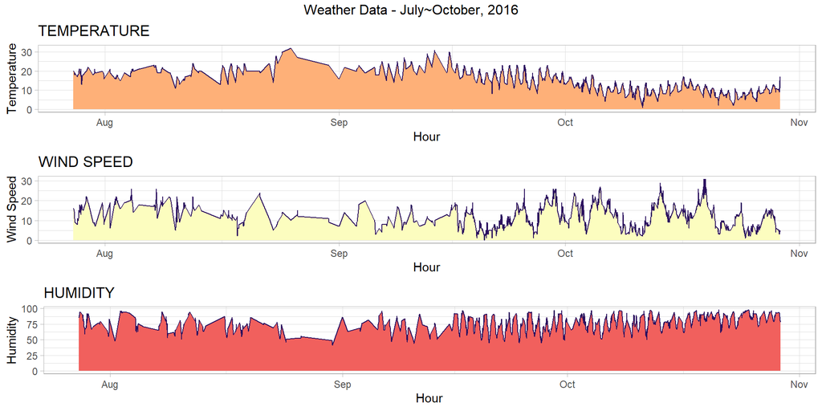

```r
# july1$station_date <- paste (july1$station_name, july1$interval60, sep= "-")
# july2$station_date <- paste (july2$station_name, july2$interval60, sep= "-")
# aug1$station_date <- paste (aug1$station_name, aug1$interval60, sep= "-")
# aug2$station_date <- paste (aug2$station_name, aug2$interval60, sep= "-")
# sep1$station_date <- paste (sep1$station_name, sep1$interval60, sep= "-")
# sep2$station_date <- paste (sep2$station_name, sep2$interval60, sep= "-")
# oct1$station_date <- paste (oct1$station_name, oct1$interval60, sep= "-")
# oct2$station_date <- paste (oct2$station_name, oct2$interval60, sep= "-")
#
# weather <- rbind(july1,july2,aug1,aug2,sep1,sep2,oct1,oct2)

weather <- read.csv("D:/OneDrive - PennO365/Semester 3/PPA/PPA Final/Final Project/data/weather_export.csv")

trains$station_date <- paste (trains$name, trains$interval60, sep= "-")
trains <- merge(x=trains,y=weather[,c("station_date","Temperature","Humidity","Wind_Speed")], by = "station_date", all.x=TRUE)

# trains$Temperature.x[is.na(trains$Temperature.x)] <- 0
# trains$Temperature.y[is.na(trains$Temperature.y)] <- 0
# trains$Humidity.x[is.na(trains$Humidity.x)] <- 0
# trains$Humidity.y[is.na(trains$Humidity.y)] <- 0
# trains$Wind_Speed.x[is.na(trains$Wind_Speed.x)] <- 0
# trains$Wind_Speed.y[is.na(trains$Wind_Speed.y)] <- 0

grid.arrange(
  ggplot(trains, aes(interval60,Temperature)) + geom_area(col="#2c115f", fill = "#feb078") +
    labs(title="TEMPERATURE", x="Hour", y="Temperature") +
      theme(plot.title = element_text(size = 10, hjust = 1, vjust = 2),
            axis.title = element_text(size = 10)) + theme_light(),
  ggplot(trains, aes(interval60,Wind_Speed)) + geom_area(col="#2c115f", fill = "#fcfdbf") +
    labs(title="WIND SPEED", x="Hour", y="Wind Speed") +
      theme(plot.title = element_text(size = 10, hjust = 1, vjust = 2),
            axis.title = element_text(size = 10)) + theme_light(),
  ggplot(trains, aes(interval60,Humidity)) + geom_area(col="#2c115f", fill = "#f1605d") +
    labs(title="HUMIDITY", x="Hour", y="Humidity")+
      theme(plot.title = element_text(size = 10, hjust = 1, vjust = 2),
            axis.title = element_text(size = 10)) + theme_light(),
  top="Weather Data - July~October, 2016")
```

### Demographic Data

We got population data for 2016 from [Statbel, the Belgian statistical office](https://statbel.fgov.be/en/open-data/population-according-km2-grid). The population density of Belgium was 370 people per sq in 2016. Here we have the visualization of people per sq km.

```r
breaks <- c(0, 50, 200, 350, 1000, Inf)
labels <- c("0-50", "50-200", "200-350", "350-1000", ">1000")

# Categorize and create new column 'popcat'
population$popcat <- cut(population$ms_population_20160101, breaks = breaks, labels = labels, include.lowest = TRUE)

# Convert data frame to sf object
population_sf <- st_as_sf(population)
```

Population Density and Rail Netowrk

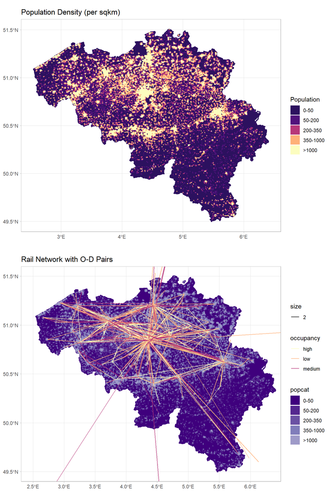

```r
# Load the RColorBrewer package
library(RColorBrewer)

reverse_palette <- function(palette) {
  rev(RColorBrewer::brewer.pal(n = 9, name = palette))
}

purple_palette <- brewer.pal(9, "Purples")

# ggplot(OD_Pair) +
#   #geom_sf(data = belgium, fill = "lightgray", color = "white") +
#   geom_sf(data = population_sf, aes(fill = popcat), color = "transparent", size = 0.5) +
#   scale_fill_manual(values = reverse_palette("Purples")) +
#   #geom_sf(data = OD_Pair, aes(color = occupancy, size = 2), inherit.aes = FALSE) +
#   ylim(min(49.5), max(51.5)) +
#   xlim(min(2.5), max(6.3)) +
#   #scale_color_manual(values = palette3b) +  # Your custom palette for color
#   theme_light()

# Visualize the map

population_sf <- st_transform(population_sf, crs = st_crs(OD_Pair))

grid.arrange(
  ggplot() +
    geom_sf(data = population_sf, aes(fill = popcat), color = "transparent", size = 0.5) +
    scale_fill_manual(values = rev(palette5)) +
    labs(title = "Population Density (per sqkm)", fill = "Population") +
    theme_light() +
    theme(legend.position = "right"),
  ggplot(OD_Pair) +
    geom_sf(data = belgium, fill = "lightgray", color = "white") +
    geom_sf(data = population_sf, aes(fill = popcat), color = "transparent", size = 0.5) +
    scale_fill_manual(values = reverse_palette("Purples")) +
    geom_sf(data = OD_Pair, aes(color = occupancy, size = 2), inherit.aes = FALSE) +
    ylim(min(49.5), max(51.5)) +
    xlim(min(2.5), max(6.3)) +
    scale_color_manual(values = palette3b) +
    theme_light() +
    labs(title = "Rail Network with O-D Pairs") +
    theme(legend.position = "right"),
  ncol = 1,
  nrow = 2,  # Specify the number of rows
  heights = c(1, 1)  # Adjust the height proportion as needed
)
```

# Exploratory Analysis

We looked at the data fro a range of perspectives, isolating different variables and exploring specific subsets of data. The plots below consider the different kinds of data (continuous and categorical variables) and the relationship between the variables. Variables that reveal clear patterns or greater contrasts across binary outcomes are more useful for the purpose of developing our model.

This project is fundamentally about the distribution of variables (occupancy, and indirectly maintenance need) in space and time. Therefore, the exploration of spatial and temporal dimensions and data, their distribution and interrelations, are at the core of this project.

## Spatial Analysis

We looked at the spatial dimension first, considering occupancy in relation to origin-destination pairs. In this case it is important to distinguish that OD pair occupancy with line occupancy, as there may be more than one way for passengers to get from point A to point B. In other words, passengers may use different lines (or combinations of lines) to get from their origin to their destination, and this could eventually have important implications when assessing system redundancies, occupancy of lines, impact of service disruptions, and options for increased efficiency.

```r
# occupancy with O-D trip (percent)

occ_OD <- trains%>%
  group_by(OD)%>%
   count(occ2)%>%
  mutate(percent = n/sum(n),
         count = n)%>%
  filter(n>=4 & percent >0.5)%>%
   dplyr::select(-n)

occ_OD_df <- as.data.frame(occ_OD)
# head(occ_OD[order(-occ_OD_df$count, -occ_OD_df$percent),],)

# merge l with occ_OD
l2 <- merge(l, occ_OD, by="OD", all.x=TRUE)
l2$occ2 <- factor(l2$occ2, level=c("low","medium","high"))
train_sf$OD_occ <- factor(ifelse(train_sf$OD %in% occ_OD$OD, train_sf$OD, "1"))
```

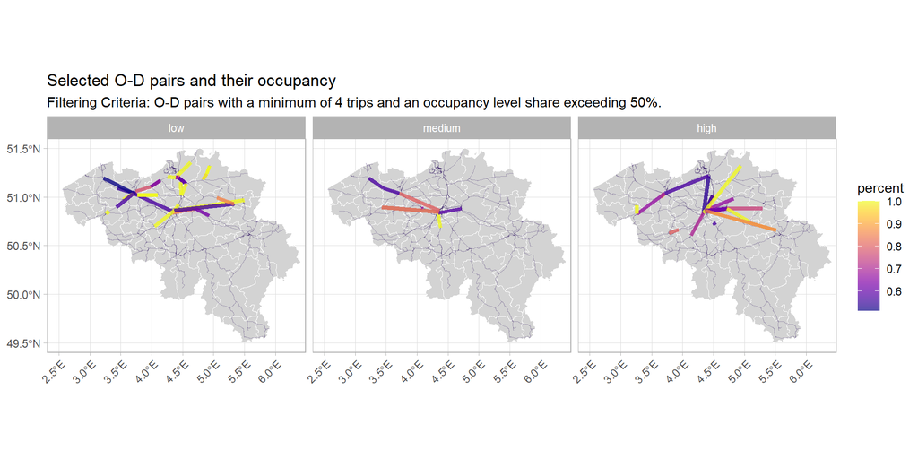

```r
# plot the trip with high percentage of certain occupancy
l2 %>%
  filter(!is.na(occ2)) %>%
  mutate(per = percent * 10) %>%
  ggplot() +
  geom_sf(data = belgium, fill = "lightgray", color = "white") +
  #geom_sf(data = stations, size = 0.5, inherit.aes = FALSE, col = "#f1605d") +
  geom_sf(data = rail, inherit.aes = FALSE, na.rm = TRUE, col = "#2c115f", lwd = 0.3, alpha = 0.3) +
  geom_sf(aes(color = percent), lwd = 1.5, fill = "transparent", alpha = 0.8) +  # Set alpha here
  scale_colour_viridis(direction = 1, discrete = FALSE, option = "C", alpha = 0.7) +  # Set alpha for Viridis
  ylim(min(49.5), max(51.5)) + #lat
  xlim(min(2.5), max(6.3)) +  #long
  facet_wrap(~occ2) +
  labs(
    title = "Selected O-D pairs and their occupancy",
    subtitle = "Filtering Criteria: O-D pairs with a minimum of 4 trips and an occupancy level share exceeding 50%."
  ) +
  theme_light() +
  theme(axis.text.x = element_text(angle = 45, hjust = 1)) +
  theme(
    legend.position = "right",  # Set legend position to bottom
    legend.box = "horizontal",    # Display legend horizontally
    legend.just = "left"
  )
```

#### Occupancy by Stations

Beyond the Origin-Destination (O-D) pairs, the specific origin and destination stations significantly influence the occupancy levels of train trips. To delve into the relationship between trip occupancy and the origin or destination station in our dataset, we grouped the `train` dataset by the “From” and “To” stations, categorizing them into three occupancy levels. Our analysis revealed a substantial impact of both the origin and destination stations on trip occupancy, as depicted in the accompanying figure. Notably, trips departing from or heading to certain stations, such as 8821964 (Tielen), consistently exhibit low occupancy levels. This pattern is observed across several stations.

Furthermore, our investigation uncovered variations in the impact of stations as origins or destinations on trip occupancy. For instance, approximately 67% of trips departing from station 8831401 (Diest) experience high occupancy, while 70% of trips heading to the same station have low occupancy. This disparity emphasizes the diverse influence of stations on trip occupancy levels. Consequently, we have decided to incorporate all “From” and “To” stations into our model to comprehensively account for these variations in trip occupancy dynamics.

```r
### from ###
occ_from <- trains%>%
  group_by(from)%>%
   count(occ2)%>%
  mutate(percent = n/sum(n),
         count = n,
         station_id= from)%>%
 # filter(n>=4 & percent >0.5)%>%
  dplyr::select(-n)

#merge with sf
stations <- stations%>%
  mutate(Geom = gsub('[(c)°]', '', geometry)) %>%
  separate(col = Geom, into = c('lat', 'lon'), sep = '\\,')
occ_from <- merge(stations[c("lat","lon","station_id")], occ_from, by= "station_id",all.y=T)
occ_from_df <- as.data.frame(occ_from)%>%
  dplyr::select(-geometry)%>%
  round_df(3)

### to ###
occ_to <- trains%>%
  group_by(to)%>%
   count(occ2)%>%
  mutate(percent = n/sum(n),
         count = n,
         station_id= to)%>%
 # filter(n>=4 & percent >0.5)%>%
  dplyr::select(-n)

# merge with sf
stations <- stations%>%
  mutate(Geom = gsub('[(c)°]', '', geometry)) %>%
  separate(col = Geom, into = c('lat', 'lon'), sep = '\\,')
occ_to <- merge(stations[c("lat","lon","station_id")], occ_to, by= "station_id",all.y=T)
occ_to_df <- as.data.frame(occ_to)%>%
  dplyr::select(-geometry)%>%
  round_df(3)

kable(head(occ_from_df[order(-occ_from_df$count, -occ_from_df$percent), ]), format = "markdown")
```

|  | station_id | lat | lon | from | occ2 | percent | count |
| --- | --- | --- | --- | --- | --- | --- | --- |
| 337 | 8892007 | 3.710675 | 51.035896 | 8892007 | low | 0.359 | 79 |
| 335 | 8892007 | 3.710675 | 51.035896 | 8892007 | medium | 0.341 | 75 |
| 64 | 8812005 | 4.360846 | 50.859663 | 8812005 | low | 0.374 | 67 |
| 200 | 8833001 | 4.715866 | 50.88228 | 8833001 | high | 0.537 | 66 |
| 336 | 8892007 | 3.710675 | 51.035896 | 8892007 | high | 0.300 | 66 |
| 62 | 8812005 | 4.360846 | 50.859663 | 8812005 | high | 0.358 | 64 |

```r
kable(head(occ_to_df[order(-occ_to_df$count,-occ_to_df$percent),]), format = "markdown")
```

|  | station_id | lat | lon | to | occ2 | percent | count |
| --- | --- | --- | --- | --- | --- | --- | --- |
| 378 | 8892007 | 3.710675 | 51.035896 | 8892007 | low | 0.435 | 73 |
| 72 | 8812005 | 4.360846 | 50.859663 | 8812005 | high | 0.403 | 73 |
| 99 | 8814001 | 4.336531 | 50.835707 | 8814001 | medium | 0.364 | 64 |
| 73 | 8812005 | 4.360846 | 50.859663 | 8812005 | low | 0.343 | 62 |
| 97 | 8814001 | 4.336531 | 50.835707 | 8814001 | high | 0.335 | 59 |
| 93 | 8813003 | 4.356801 | 50.845658 | 8813003 | medium | 0.349 | 58 |

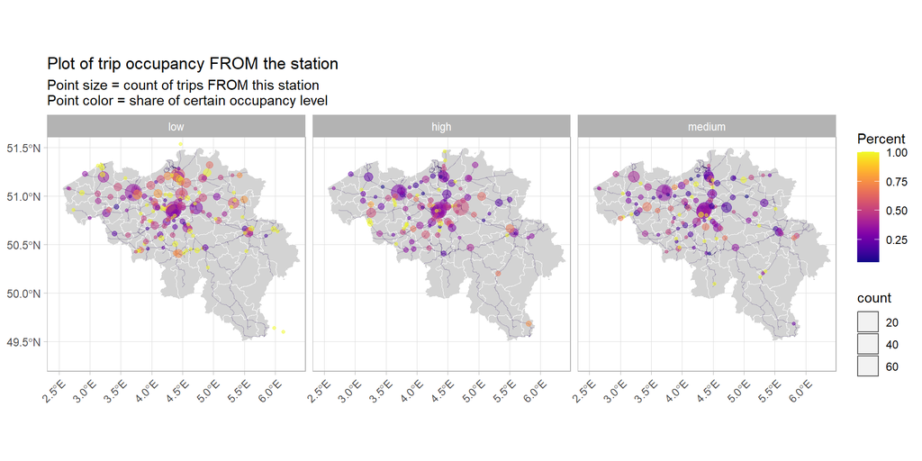

```r
library(viridis)

ggplot(occ_from) +
    geom_sf(data = belgium, fill = "lightgray", color = "white") +
    geom_sf(data = rail, inherit.aes = FALSE, na.rm = TRUE, col = "#2c115f", lwd = 0.2, alpha = 0.3) +
    geom_sf(data = occ_from, aes(color = percent, size = count), alpha = 0.5) +
    scale_color_viridis(direction = 1, discrete = FALSE, option = "C") +
    facet_wrap(~occ2) + #this is the line of code that generates diff maps for each cat (low, med, high)
    ylim(min(49.3), max(51.5)) + #lat
    xlim(min(2.5), max(6.3)) +
    labs(
      title = "Plot of trip occupancy FROM the station",
      subtitle = "Point size = count of trips FROM this station\nPoint color = share of certain occupancy level",
      color = "Percent") +
    theme_light() +
  theme(axis.text.x = element_text(angle = 45, hjust = 1))
```

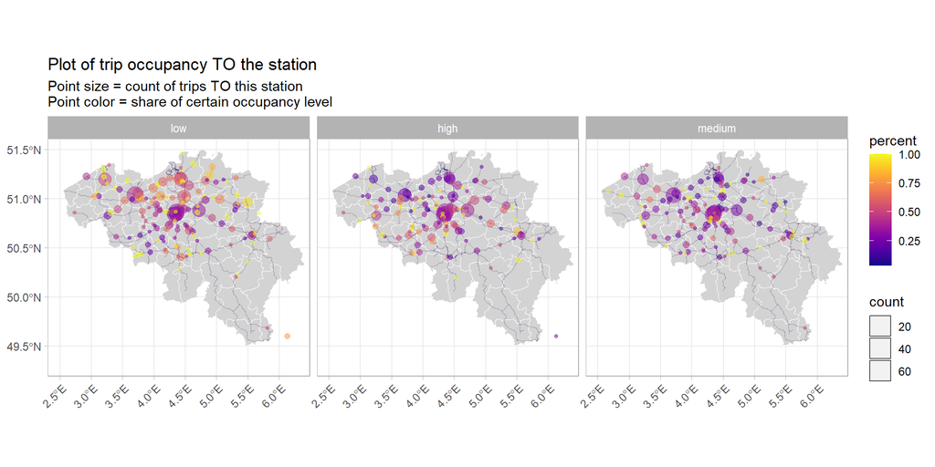

```r
ggplot(occ_to) +
    geom_sf(data = belgium, fill = "lightgray", color = "white") +
    geom_sf(data = rail, inherit.aes = FALSE, na.rm = TRUE, col = "#2c115f", lwd = 0.2, alpha = 0.3) +
    geom_sf(data = occ_to, aes(color = percent, size = count), alpha = 0.5) +
    scale_colour_viridis(direction = 1, discrete = FALSE, option = "C") +
    facet_wrap(~occ2) +
    ylim(min(49.3), max(51.5)) + #lat
    xlim(min(2.5), max(6.3)) +
    labs(
      title = "Plot of trip occupancy TO the station",
      subtitle = "Point size = count of trips TO this station\nPoint color = share of certain occupancy level") +
    theme_light() +
  theme(axis.text.x = element_text(angle = 45, hjust = 1))
```

#### Occupancy by Lines

We considered the impact of the serving line, referred to as the “vehicle” in our dataset. Adopting a methodology similar to our previous approach, we grouped the data based on line type. Specifically, we focused on selecting lines where 80% of the trips belonged to low, medium, or high occupancy categories. Additionally, we imposed a criterion of more than 5 trips for a line to be included in our analysis. This strategic selection aims to avoid lines with too few trips, which might exhibit unusual characteristics that could adversely affect the model. By incorporating the serving line into our investigation, we aim to enhance the comprehensiveness of our understanding of factors influencing occupancy levels in train trips.

```r
occ_veh <- trains%>%
  group_by(vehicle)%>%
   count(occ2)%>%
  mutate(percent = n/sum(n),
         vehicle_id = vehicle,
         count = n)%>%
   filter(n>=6, percent>=0.8)%>%
dplyr::select(-n)
occ_veh_df <- as.data.frame(occ_veh)%>%
  round_df(3)

line$nr_of_stops <- as.numeric(as.character(line$nr_of_stops))
sep_stat_line <- as.data.frame(str_split_fixed(line$stopping_station_ids, ",",34))

sep_stat_line <- sep_stat_line %>%
  mutate_all(funs(gsub("'", "", .)))%>%
  mutate_all(funs(gsub("]", "", .)))%>%
  mutate(V1 = substr(V1, 2, 10))

# join station with line info
sep_stat_line <- cbind(line,sep_stat_line)
sep_stat_line <-
  sep_stat_line%>%
  dplyr::select(-Unnamed..0, -Unnamed..0.1)

# wide to long
v_stat_line <- reshape(sep_stat_line,
                       varying=c(6:39),
                       timevar = "Order",
                       idvar=c("vehicle_id"),
                       v.names="station_id",
                       direction="long")
v_stat_line <- v_stat_line%>%mutate_all(funs(gsub(" ", "", .)))%>%
  mutate(station_id = substr(station_id,3,9))%>%
  filter(station_id!="")%>%
  dplyr::select(-stopping_station_ids)

# add geometry to each station
stat_order_sf <- merge(stations[c("avg_stop_times", "station_id","geometry")], v_stat_line, by = "station_id",all=T)

# if the % of certain type of occupancy is larger than 0.8 (and count >=6), then 1,  otherwise 0
stat_order_sf$occ_veh<- ifelse(stat_order_sf$vehicle_id %in% occ_veh$vehicle_id,1,0)

# only select the stations exist in trains
stat_order_sf <- subset(stat_order_sf, stat_order_sf$station_id %in% trains$from | stat_order_sf$station_id %in% trains$to)

# merge occupancy into station order_sf
veh_sf <- merge(stat_order_sf,occ_veh, by = "vehicle_id", all.x=T)
veh_sf <- veh_sf%>%
  filter(!is.na(occ2))
```

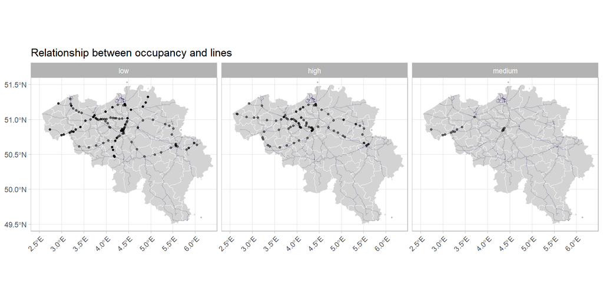

```r
ggplot()+
  geom_sf(data = belgium, fill = "lightgray", color = "white") +
  geom_sf(data=rail, inherit.aes = FALSE,na.rm=T, col="#2c115f", lwd=0.2, alpha=0.3) +
  geom_sf(data=stat_order_sf, color = "grey",size=0.5, alpha=0.4) +
  geom_sf(data=veh_sf, size=1, alpha = 0.5) +
  facet_wrap(~occ2)+
ylim(min(49.5), max(51.5))+ #lat
xlim(min(2.5), max(6.3))+
  theme_light()+
  theme(axis.text.x = element_text(angle = 45, hjust = 1)) +
   labs(title="Relationship between occupancy and lines")
```

```r
train_sf$vehicle <- as.character(train_sf$vehicle)
train_sf$veh_occ <- as.factor(ifelse(train_sf$vehicle %in% occ_veh$vehicle, train_sf$vehicle, "1"))
```

## Temporal Analysis

We looked at the frequency of occupancy categories across a range of time scales:

- by week: counted as “week of the year” to have a consistent way of identifying weeks across any month;
- by day of the week: to identify tendencies between the week and weekend;
- by hour of the day: to look at commuter patters and similar behavior;
- by “rush hour”: to isolate effects of known high demand time windows.

The resulting series are plotted below.

```r
trains2 <- trains%>%
  group_by(interval60)%>%
   count(occupancy)%>%
  mutate(percent = n/sum(n),
         count = n)%>%
  filter(n>=4 & percent >0.5)%>%
   dplyr::select(-n)
#unique(trains$interval60)
```

#### Occupancy by week

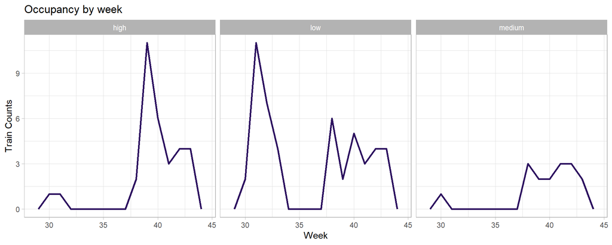

```r
library(ggplot2)

trains3 <- trains2 %>%
  mutate(week = week(interval60))

ggplot(trains3)+
     geom_freqpoly(aes(week), binwidth = 1, lwd=1, col="#2c115f")+
  labs(title="Occupancy by week",
       x="Week",
       y="Train Counts")+
           facet_wrap(~occupancy)+
     theme_light()
```

#### Occupancy by day of the week

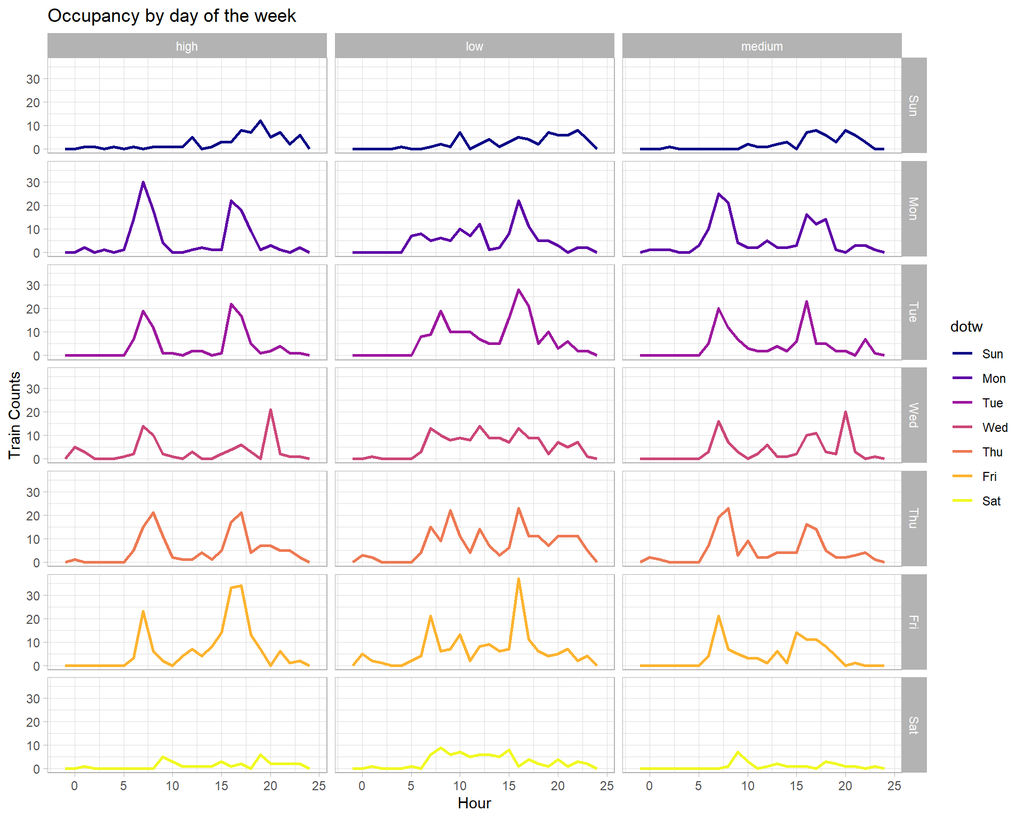

```r
ggplot(trains %>%
         mutate(hour = hour(date_time)))+
  geom_freqpoly(aes(hour, color = dotw), binwidth = 1, lwd=1)+
  scale_color_viridis(discrete=TRUE, option = "C") +
  labs(title="Occupancy by day of the week",
       x="Hour",
       y="Train Counts")+
           facet_grid(dotw ~ occupancy) +
     theme_light()
```

#### Occupancy by hour of the day

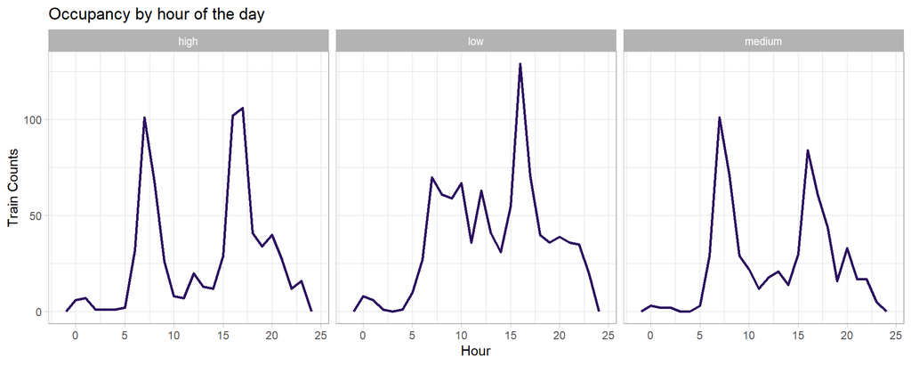

```r
ggplot(trains %>%mutate(hour = hour(date_time)))+
     geom_freqpoly(aes(hour), binwidth = 1, lwd=1, col="#2c115f")+
  labs(title="Occupancy by hour of the day",
       x="Hour",
       y="Train Counts")+
           facet_wrap(~occupancy)+
     theme_light()
```

#### Occupancy in relation to rush hour

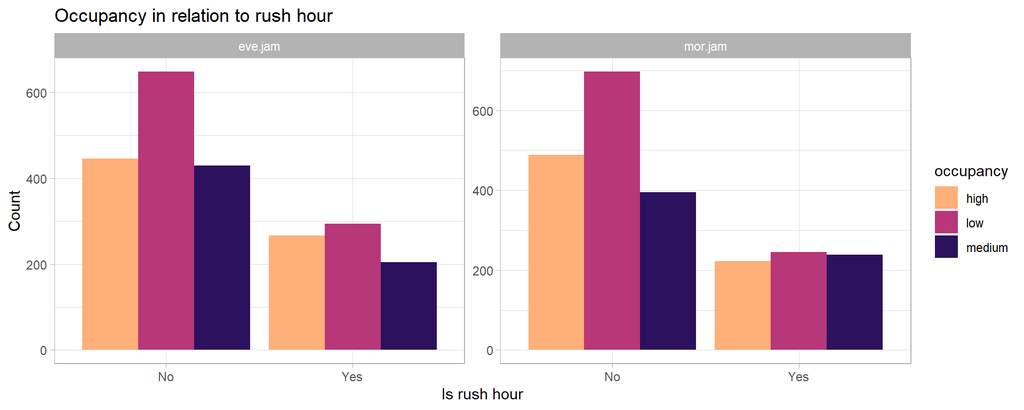

```r
trains$mor.jam[trains$mor.jam==0] <- 'No'
trains$mor.jam[trains$mor.jam==1] <- 'Yes'
trains$eve.jam[trains$eve.jam==0] <- 'No'
trains$eve.jam[trains$eve.jam==1] <- 'Yes'

trains %>%
  dplyr::select(occupancy, mor.jam,eve.jam) %>%
  gather(Variable, value, -occupancy)  %>%
  count(Variable, value, occupancy)%>%
  ggplot(., aes(value, n, fill = occupancy)) +
  geom_bar(position = "dodge", stat="identity") +
  facet_wrap(~Variable, scales="free") +
  scale_fill_manual(values = palette3c) +
  labs(x="Is rush hour", y="Count",
       title = "Occupancy in relation to rush hour")+
  guides(color = guide_legend(title = "Occupancy Category",
                              override.aes = list(color = c(high = "#feb078", medium = "#b73779", low = "#2c115f"))))+
  theme_light()
```

#### Occupancy by Temperature

We also looked into more specific trip segmentation, combining weather variables with day-of-the-week and occupancy. The resulting series are shown below.

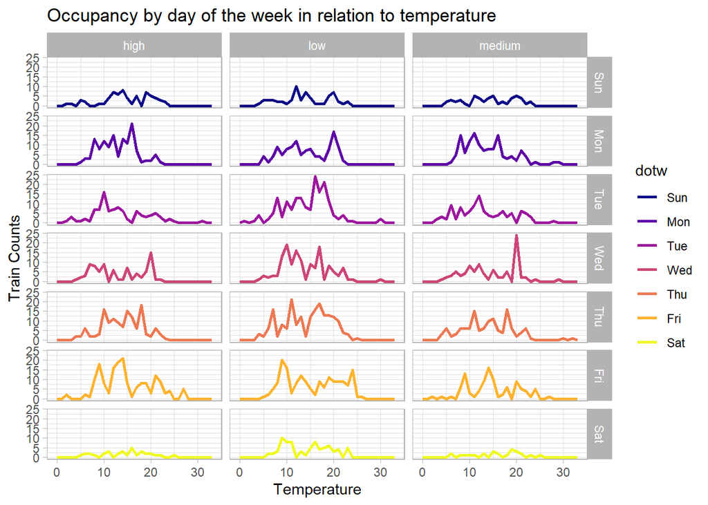

```r
ggplot(trains %>%
         mutate(hour = hour(interval60)) %>%
         dplyr::filter(occ2 == "high" | occ2 == "medium" | occ2 == "low") )+
  geom_freqpoly(aes(Temperature, color = dotw), binwidth = 1, lwd=1)+
  scale_color_viridis(discrete=TRUE, option = "C") +
  labs(title="Occupancy by day of the week in relation to temperature",
       x="Temperature",
       y="Train Counts")+
           facet_grid(dotw ~ occupancy) +
     theme_light()
```

While there are no strong patterns, there seems to be a mild tendency for more high occupancy trips when temperatures range between 7 and 15 degrees and an increase in lower occupancy when temperature climb above 15 degrees. while further data and analysis would be necessary to draw conclusions, hypotheses include commuters choosing between different modes of transportation or opting not to travel (to enjoy the weather)

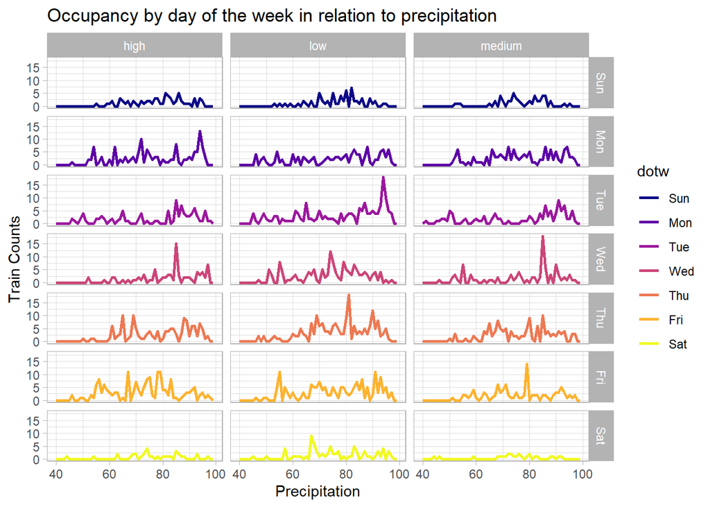

```r
ggplot(trains %>%
         mutate(hour = hour(interval60)) %>%
         dplyr::filter(occ2 == "high" | occ2 == "medium" | occ2 == "low") )+
  geom_freqpoly(aes(Humidity, color = dotw), binwidth = 1, lwd=1)+
  scale_color_viridis(discrete=TRUE, option = "C") +
  labs(title="Occupancy by day of the week in relation to precipitation",
       x="Precipitation",
       y="Train Counts")+
           facet_grid(dotw ~ occupancy) +
     theme_light()
```

#### Occupancy by Wind

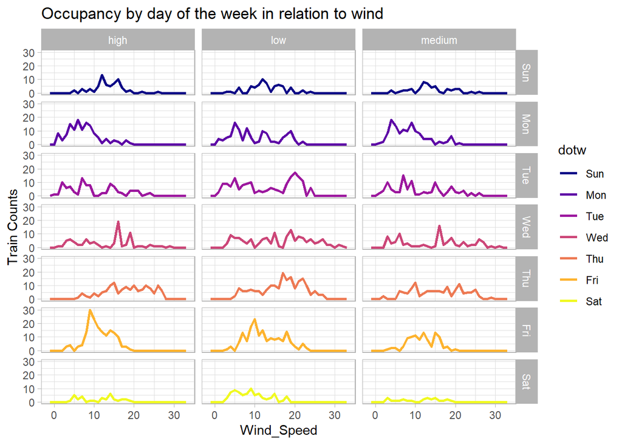

```r
ggplot(trains %>%
         mutate(hour = hour(interval60)) %>%
         filter(occ2 == "high" | occ2 == "medium" | occ2 == "low") )+
  geom_freqpoly(aes(Wind_Speed, color = dotw), binwidth = 1, lwd=1)+
  scale_color_viridis(discrete=TRUE, option = "C") +
  labs(title="Occupancy by day of the week in relation to wind",
       x="Wind_Speed",
       y="Train Counts")+
           facet_grid(dotw ~ occupancy) +
     theme_light()
```

# Feature Engineeering

In the process of feature engineering, our aim is to investigate the interplay among different stations. We have centered our inquiries on several key questions:

1. **Impact of Nearby Stations:** How does the presence of neighboring stations influence the occupancy of a particular station?
2. **Significance of Station Density:** Will the density of stations in a specific area emerge as a crucial factor in occupancy prediction?
3. **Proximity to High Density Settlements:** Is there a correlation between proximity to major population centers, such as Brussels, and higher station occupancy?
4. **Temporal Lags:** Is there a discernible pattern or time lag effect in the relationship between historical station data and current occupancy levels?

## Spatial Process

The next step is to look at areas around each station. We’re counting how many other stations are within a certain distance. To make it easier to use this information in our model, we’re grouping these counts into different levels. This helps us better understand and use the impact of nearby stations on our predictions.

```r
trains$occupancy <- ordered(trains$occupancy,levels=c("low","medium","high") )

stations_d <-
  stations %>%
  dplyr::select(geometry) %>%
  na.omit() %>%
  st_transform(31370) %>%
  distinct() %>%
  st_transform(st_crs(stations))

stations$station.Buffer =
  stations%>%
  st_buffer(26400) %>%
  aggregate(mutate(stations_d, station.Buffer = 1),., sum) %>%
  pull(station.Buffer)

stations <-
  stations  %>%
  mutate(station_buffer_cat=case_when(
    station.Buffer <20 ~ "<20",
    station.Buffer >=20 & station.Buffer <40 ~ "20-40",
    station.Buffer >=40 & station.Buffer<60 ~ "40-60",
    station.Buffer >= 60 & station.Buffer < 80 ~ "60-80",
    station.Buffer >= 80 & station.Buffer < 100 ~ "80-100",
    station.Buffer >= 100 & station.Buffer < 120 ~ "100-120",
    station.Buffer >= 120 & station.Buffer < 140 ~ "120-140",
  ))

trains <- mutate(trains,
                 station_buffer_cat = stations$station_buffer_cat[match(trains$to, stations$station_id)],
                 avg_stop_time = stations$avg_stop_time[match(trains$to, stations$station_id)])


trains <-
  trains %>%
  mutate(time_of_day = case_when(hour(interval60) < 7 | hour(interval60) > 18 ~ "Overnight",
                        hour(interval60) >= 7 & hour(interval60) < 10 ~ "AM Rush",
                        hour(interval60) >= 10 & hour(interval60) < 15 ~ "Mid-Day",
                        hour(interval60) >= 15 & hour(interval60) <= 18 ~ "PM Rush"))
```

In the process of preparing our data for predicting train occupancy, we’re looking at how nearby train stations and the time of day might impact the number of people on trains. This involved categorizing station activity across various time segments, including peak morning and evening periods. Subsequently, we established spatial zones around each station, employing a geospatial approach to quantify the proximity of neighboring stations. This spatial analysis aimed to discern whether higher station density in the vicinity correlates with increased ridership. Furthermore, we incorporated a temporal dimension by categorizing train trips into distinct time-of-day periods, specifically during morning rush, mid-day, and evening rush hours. To refine our understanding, we leveraged the k-nearest neighbors function to identify the three nearest stations for each trip and ascertain their average distances. By doing this, we’re making sure our predictions account for factors like station density and distance, giving us a better understanding of what influences how crowded a train might be.

```r
### KNN

stations_x = stations
stationsdist = nn_function(st_coordinates(stations), st_coordinates(stations), 3)
stations_x$stationdist = stationsdist$pointDistance

trains %>%
  left_join(dplyr::select(stations_x, c(name, stationdist)), by = c("to" = "name")) %>%
  filter(stationdist < 15000)

stations_x <- stations_x %>%
  mutate(stationdist_pct_to=case_when(
    stationdist < 1000 ~ "<1000",
    stationdist >= 1000 & stationdist < 2250 ~ "1000-2250",
    stationdist >= 2250 & stationdist < 2750 ~ "2250-2750",
    stationdist >= 2750 & stationdist < 3750 ~ "2750-3750",
    stationdist >= 3750 & stationdist < 4250 ~ "4000-4250",
    stationdist >= 4250 & stationdist < 6000 ~ "4250-6000",
    stationdist >= 6000 & stationdist < 7500 ~ "6000-7500",
    stationdist >= 7500 ~ ">7500",
  ))
```

## Temporal Process

In this temporal process of feature engineering, we investigate the correlation between time lags and train occupancy. The dataset is organized based on the origin station and the chronological order of intervals. Subsequently, lag features are created to capture the historical occupancy levels at various time intervals. These include lag features for the previous hour, 2 hours, 3 hours, 4 hours, 12 hours, 1 day, and 1 week. Each lag feature represents the occupancy level at a specific time in the past, allowing us to explore potential temporal dependencies in the data. The occupancy levels and lag features are then transformed into factors for categorical representation.

`lagHour and occ2`: There is a weak positive correlation (0.14) between the occupancy level of the current hour and the next hour. This means that if the occupancy is high in the current hour, there is a slight tendency for it to be higher in the next hour.

`lag2Hours and occ2`: There is a weak positive correlation (0.07) between the occupancy level of the current hour and the hour two hours later. This suggests a slight influence of the current occupancy on the occupancy two hours later.

There was negligible influence of any of the other lags. Based on this, we then checked for influence of 15 mins and 30 mins.

`lag15min and occ2`: The correlation coefficient of 0.14 suggests a weak positive correlation between the occupancy level in the current 15-minute interval and the occupancy level 15 minutes later. This implies that higher occupancy in the current 15-minute interval is associated with a slightly higher occupancy 15 minutes later.

`lag30min and occ2`: The correlation coefficient of 0.08 indicates a weak positive correlation between the occupancy level in the current 30-minute interval and the occupancy level 30 minutes later. Similar to the previous case, higher occupancy in the current 30-minute interval is weakly associated with a slightly higher occupancy 30 minutes later.

These correlations suggest a modest temporal dependence between the current occupancy level and future occupancy levels at 15-minute, 30-minute intervals, 1 hour and 2 hours.

```r
trains <- trains %>%
  arrange(from, interval60) %>%
  mutate(
    lagHour = lag(occ2, 1),
    lag2Hours = lag(occ2, 2),
    lag3Hours = lag(occ2, 3),
    lag4Hours = lag(occ2, 4),
    lag12Hours = lag(occ2, 12),
    lag1day = lag(occ2, 24),
    lag1week = lag(occ2, 168)
  )

# Arrange the data
trains_transform <- as.data.frame(trains) %>%
  arrange(from, interval60) %>%
  # Create lag features
  mutate(
    lagHour = as.numeric(lag(occ2, 1)),
    lag2Hours = as.numeric(lag(occ2, 2)),
    lag3Hours = as.numeric(lag(occ2, 3)),
    lag4Hours = as.numeric(lag(occ2, 4)),
    lag12Hours = as.numeric(lag(occ2, 12)),
    lag1day = as.numeric(lag(occ2, 24)),
    lag1week = as.numeric(lag(occ2, 168)),
    # Convert 'occ2' to numeric
    occ2_numeric = as.numeric(factor(occ2))
  )

# Convert lag columns to numeric
lag_columns <- c("lagHour", "lag2Hours", "lag3Hours", "lag4Hours", "lag12Hours", "lag1day", "lag1week")
trains_transform[lag_columns] <- lapply(trains_transform[lag_columns], function(x) as.numeric(as.character(x)))

# Group by interval60, calculate the mean for lag and occ2_numeric variables
lag_summary <- trains_transform %>%
  group_by(interval60) %>%
  summarise(across(starts_with("lag"), mean, na.rm = TRUE), occ2_numeric = mean(occ2_numeric, na.rm = TRUE), .groups = "drop")

# Select relevant columns for correlation analysis
lag_columns <- c("lagHour", "lag2Hours", "lag3Hours", "lag4Hours", "lag12Hours", "lag1day", "lag1week", "occ2_numeric")

# Subsetting the dataframe with selected columns
lag_data <- trains_transform[, lag_columns]

# Calculate correlation matrix
correlation_matrix <- cor(lag_data, use = "complete.obs")
correlation_table <- correlation_matrix["occ2_numeric", names(correlation_matrix) != "occ2_numeric"]
kable(correlation_table, format = "markdown")

# 15 MINS LAG
trains_transform_interval15 <- as.data.frame(trains) %>%
  arrange(from, interval15) %>%
  # Create lag features
  mutate(
    lag15min = as.numeric(lag(occ2, 1)),
    lag30min = as.numeric(lag(occ2, 2)),
    # Convert 'occ2' to numeric
    occ2_numeric = as.numeric(factor(occ2))
  )

# Convert lag columns to numeric
lag_columns_interval15 <- c("lag15min", "lag30min", "occ2_numeric")
trains_transform_interval15[lag_columns_interval15] <- lapply(trains_transform_interval15[lag_columns_interval15], function(x) as.numeric(as.character(x)))

# Group by interval15, calculate the mean for lag and occ2_numeric variables
lag_summary_interval15 <- trains_transform_interval15 %>%
  group_by(interval15) %>%
  summarise(across(starts_with("lag"), mean, na.rm = TRUE), occ2_numeric = mean(occ2_numeric, na.rm = TRUE), .groups = "drop")

# Select relevant columns for correlation analysis
lag_columns_interval15 <- c("lag15min", "lag30min", "occ2_numeric")

# Subsetting the dataframe with selected columns
lag_data_interval15 <- trains_transform_interval15[, lag_columns_interval15]

# Calculate correlation matrix
correlation_matrix_interval15 <- cor(lag_data_interval15, use = "complete.obs")

# Display the correlation matrix
print(correlation_matrix_interval15)
```

# Modeling

## Methodology

For this project, we use Multinomial Logistic Regression as the modeling technique. The dependent variable encompasses three categories representing train occupancy levels: **low, medium, and high**.

1. **Variable Selection:**
   - Various predictor variables were considered in the modeling process, including week, day of the week (dotw), vehicle (veh), hour, morning jam (mor.jam), evening jam (eve.jam), distance, from, to, stop_times_from, stop_times_to, lagHour, lag15min, station_buffer_cat, avg_stop_time, Temperature.x, Humidity.x, Wind_Speed.x, and time_of_day.
2. **Model Iterations:**
   - Multiple iterations were performed by training several models (m1, m2, m3, m_all) with different combinations of predictor variables.
   - Additional features were engineered, including lag variables, station buffer categories, average stop time, and environmental factors.
3. **Stepwise Model Selection:**
   - The stepwise model selection procedure (`stepAIC`) was applied to the comprehensive model (`m_all`) to iteratively choose a subset of predictor variables that optimized the model’s performance. This step helps prevent overfitting by selecting only relevant features.

When predicting the occupancy level through multinomial logistic regression, the model calculates the probability for each occupancy level and ultimately selects the one with the highest likelihood as the predicted outcome.

For instance, in cases where the observed occupancy is high but the model predicts it as low, it implies that the calculated probability for “low” is higher than that for “high,” leading the model to classify the occupancy level as low.

```r
# add 15 min lag
trains <- trains %>%
  arrange(from, interval60) %>%
  mutate(
    lag15min = lag(occ2, 1)
  )


trains <-
  trains %>%
  mutate( mor.jam = factor(mor.jam),
        eve.jam = factor(eve.jam))

trains$veh <- as.factor(trains$veh)
trains$week <- as.factor(trains$week)

set.seed(123)
trainIndex <- createDataPartition(
              y = paste(trains$occ2, trains$to, trains$veh_occ,  trains$OD_occ, trains$from, trains$dowt, p = .60),
              list = FALSE,
              times = 1)
yTrain <- trains[ trainIndex,]
yTest  <- trains[-trainIndex,]

yTrain$occ2 <- as.factor(yTrain$occ2)

m1 <- multinom(occ2 ~  week + dotw + veh + hour  + mor.jam + eve.jam + distance + from + to+ stop_times_from + stop_times_to, data = yTrain, MaxNWts =10000000)

m2 <- multinom(occ2 ~  week + dotw + veh + hour  + mor.jam + eve.jam + distance + from + to + stop_times_from + stop_times_to + lagHour + lag15min, data = yTrain, MaxNWts =10000000)

m3 <- multinom(occ2 ~  week + dotw + veh + hour  + mor.jam + eve.jam + distance + from + to + stop_times_from + stop_times_to + lagHour + lag15min + station_buffer_cat + avg_stop_time + time_of_day, data = yTrain, MaxNWts =10000000)

m_all <- multinom(occ2 ~  week + dotw + veh + hour  + mor.jam + eve.jam + distance + from + to + stop_times_from + stop_times_to + lagHour + lag15min + station_buffer_cat + avg_stop_time + Temperature + Humidity + Wind_Speed + time_of_day, data = yTrain, MaxNWts =10000000)

step.model <- stepAIC(m_all, direction = "backward", trace = TRUE)
```

```r
## TESTING
testProbs <- data.frame(Observe = as.factor(yTest$occ2),
                        Predict = predict(m1, newdata=yTest, "class"),
                 pre = predict(m1, newdata=yTest, "probs"),
                 from = yTest$from,
                 to = yTest$to,
                 OD = yTest$OD,
                 week = yTest$week,
                 hour = yTest$hour,
                 interval60 = yTest$interval60,
                 date = yTest$date)
testProbs <- merge(l[c("geometry","OD")], testProbs, by="OD", all.y=T)
testProbs <- testProbs[c(7,8,9, 10,11,12,1,2,3,4,5,6,13)]
testProbs_table <- as.data.frame(testProbs)%>%
  round_df(3)%>%
  dplyr::select(from, to, date, Observe, Predict, pre.low, pre.high, pre.medium)

kable(testProbs_table[1:10,], caption =  "Predict M1") %>%
  kable_styling("striped", full_width = F) %>%
  kable_styling() %>%
  scroll_box(width = "800px", height = "200px")

#######

testProbs_m2 <- data.frame(Observe = as.factor(yTest$occ2),
                        Predict = predict(m2, newdata=yTest, "class"),
                 pre = predict(m2, newdata=yTest, "probs"),
                 from = yTest$from,
                 to = yTest$to,
                 OD = yTest$OD,
                 week = yTest$week,
                 hour = yTest$hour,
                 interval60 = yTest$interval60,
                 date = yTest$date)
testProbs_m2 <- merge(l[c("geometry","OD")], testProbs_m2, by="OD", all.y=T)
testProbs_m2 <- testProbs_m2[c(7,8,9, 10,11,12,1,2,3,4,5,6,13)]
testProbs_table_2 <- as.data.frame(testProbs_m2)%>%
  round_df(3)%>%
  dplyr::select(from, to, date, Observe, Predict, pre.low, pre.high, pre.medium)

kable(testProbs_table_2[1:10,], caption =  "Predict M2") %>%
  kable_styling("striped", full_width = F) %>%
  kable_styling() %>%
  scroll_box(width = "800px", height = "200px")

######
testProbs_m_all <- data.frame(Observe = as.factor(yTest$occ2),
                        Predict = predict(m_all, newdata=yTest, "class"),
                 pre = predict(m_all, newdata=yTest, "probs"),
                 from = yTest$from,
                 to = yTest$to,
                 OD = yTest$OD,
                 week = yTest$week,
                 hour = yTest$hour,
                 interval60 = yTest$interval60,
                 date = yTest$date)
testProbs_m_all <- merge(l[c("geometry","OD")], testProbs_m_all, by="OD", all.y=T)
testProbs_m_all <- testProbs_m_all[c(7,8,9, 10,11,12,1,2,3,4,5,6,13)]
testProbs_table_all <- as.data.frame(testProbs_m_all)%>%
  round_df(3)%>%
  dplyr::select(from, to, date, Observe, Predict, pre.low, pre.high, pre.medium)

kable(testProbs_table_all[1:10,], caption =  "Predict Kitchen Sink") %>%
  kable_styling("striped", full_width = F) %>%
  kable_styling() %>%
  scroll_box(width = "800px", height = "200px")

###########
testProbs_m3 <- data.frame(Observe = as.factor(yTest$occ2),
                        Predict = predict(m3, newdata=yTest, "class"),
                        pre = predict(m3, newdata=yTest, "probs"),
                        from = yTest$from,
                        to = yTest$to,
                        OD = yTest$OD,
                        week = yTest$week,
                        hour = yTest$hour,
                        interval60 = yTest$interval60,
                        date = yTest$date)
testProbs_m3 <- merge(l[c("geometry","OD")], testProbs_m3, by="OD", all.y=T)
testProbs_m3 <- testProbs_m3[c(7,8,9, 10,11,12,1,2,3,4,5,6,13)]
testProbs_table_3 <- as.data.frame(testProbs_m3)%>%
  round_df(3)%>%
  dplyr::select(from, to, date, Observe, Predict, pre.low, pre.high, pre.medium)

kable(testProbs_table_3[1:10,], caption =  "Predict M3") %>%
  kable_styling("striped", full_width = F) %>%
  kable_styling() %>%
  scroll_box(width = "800px", height = "200px")

##########

testProbs_step <- data.frame(Observe = as.factor(yTest$occ2),
                        Predict = predict(step.model, newdata=yTest, "class"),
                 pre = predict(step.model, newdata=yTest, "probs"),
                 from = yTest$from,
                 to = yTest$to,
                 OD = yTest$OD,
                 week = yTest$week,
                 hour = yTest$hour,
                 interval60 = yTest$interval60,
                 date = yTest$date)
testProbs_step <- merge(l[c("geometry","OD")], testProbs_step, by="OD", all.y=T)
testProbs_step <- testProbs_step[c(7,8,9, 10,11,12,1,2,3,4,5,6,13)]
testProbs_table_step <- as.data.frame(testProbs_step)%>%
  round_df(3)%>%
  dplyr::select(from, to, date, Observe, Predict, pre.low, pre.high, pre.medium)

kable(testProbs_table_step[1:10,], caption =  "Predict Best Fit") %>%
  kable_styling("striped", full_width = F) %>%
  kable_styling() %>%
  scroll_box(width = "800px", height = "200px")
```

### Accuracy

```r
#install.packages("yardstick")
library(yardstick)

caret::confusionMatrix(testProbs$Observe, testProbs$Predict,
                       positive = "low")

caret::confusionMatrix(testProbs_m2$Observe, testProbs_m2$Predict,
                       positive = "low")

caret::confusionMatrix(testProbs_m3$Observe, testProbs_m3$Predict,
                       positive = "low")

caret::confusionMatrix(testProbs_m_all$Observe, testProbs_m_all$Predict,
                       positive = "low")

caret::confusionMatrix(testProbs_step$Observe, testProbs_step$Predict,
                       positive = "low")
```

### Model Evaluation (m3):

- **Confusion Matrix and Statistics:**

Further we validate the model using cross-validation techniques to ensure robustness and generalizability.

## Goodness of Fit

### Cross Validation

The AUC (Area Under the Curve) value for model m3 is 0.6864. AUC is a metric commonly used to evaluate the performance of a classification model, particularly in the context of ROC curves. In this case, a higher AUC value indicates that the model m3 has a better ability to distinguish between the different classes (low, medium, and high occupancy levels) compared to a random classifier. An AUC of 0.5 suggests random performance, while an AUC of 1.0 indicates perfect discrimination.

With an AUC of 0.6864, the model m3 demonstrates a moderate to good discriminatory ability, suggesting that it performs reasonably well in predicting the occupancy levels across the three categories.

```r
#install.packages("cvms")
library(cvms)
library(pROC)

fitControl <- trainControl(method = "cv", number = 10)
set.seed(123)

library(pROC)
#conflicted::conflicts_prefer(yardstick::precision)

# Predictions for each model
pred_m1 <- predict(m1, newdata = yTest, "class")
pred_m2 <- predict(m2, newdata = yTest, "class")
pred_m3 <- predict(m3, newdata = yTest, "class")
pred_m_all <- predict(m_all, newdata = yTest, "class")

# Actual outcomes
actual <- yTest$occ2
actual <- as.factor(actual)

# Confusion matrices
# conf_matrix_m1 <- confusionMatrix(pred_m1, actual)
# conf_matrix_m2 <- confusionMatrix(actual, pred_m2)
# conf_matrix_m_all <- confusionMatrix(actual, pred_m_all)

# AUC
#roc_m1 <- multiclass.roc(actual, as.numeric(pred_m1))
#roc_m2 <- multiclass.roc(actual, as.numeric(pred_m2))
roc_m3 <- multiclass.roc(actual, as.numeric(pred_m3))
#roc_m_all <- multiclass.roc(actual, as.numeric(pred_m_all))

# Print results
#cat("AUC for m1:", auc(roc_m1), "\n")
#cat("AUC for m2:", auc(roc_m2), "\n")
cat("AUC for m3:", auc(roc_m3), "\n")
```

```
## AUC for m3: 0.6864023077
```

```r
#cat("AUC for m_all:", auc(roc_m_all), "\n")
```

```r
# Define the control parameters for k-fold cross-validation
fitControl <- trainControl(method = "cv", number = 5)

library(mice)
library(nnet)
library(cvms)

m3_formula <- occ2 ~ week + dotw + veh + hour + mor.jam + eve.jam + distance + from + to + stop_times_from + stop_times_to + lagHour + lag15min + station_buffer_cat + avg_stop_time + time_of_day

# Define the formula for the multinomial logistic regression
m3_formula <- occ2 ~ week + dotw + veh + hour + mor.jam + eve.jam + distance + from + to + stop_times_from + stop_times_to + lagHour + lag15min + station_buffer_cat + avg_stop_time + time_of_day

# Create a data frame with your features and target variable
data_df <- data.frame(yTrain)

# Create a vector indicating the groups for LOGO-CV
groups <- factor(data_df$your_grouping_variable)  # Replace with your actual grouping variable

# Perform LOGO-CV for the m3 model
cv_results <- cross_validate(data_df, groups, m3_formula, multinom, MaxNWts = 10000000)

# View the cross-validation results
print(cv_results)
```

### Cost Benefit Analysis

In a cost-benefit analysis (CBA) for occupancy predictions, especially when dealing with scenarios like predicting line closures, it’s essential to consider various factors beyond the accuracy metrics. Here are some key considerations:

**1. False Positives and False Negatives:**

- **False Positives (Type I Errors):** Occur when the model predicts high occupancy, but the observed occupancy is low. This could result in unnecessary maintenance or service disruptions, incurring extra costs.
- **False Negatives (Type II Errors):** Occur when the model predicts low occupancy, but the observed occupancy is high. This is particularly critical as it may lead to unplanned service disruptions, potentially impacting customer satisfaction and revenue.

**2. Operational Impact:**

- **Downtime Costs:** Consider the costs associated with unnecessary downtime during maintenance due to false positives.
- **Service Disruption Costs:** Assess the costs associated with service disruptions resulting from false negatives, including compensation to passengers, reputation damage, and potential revenue loss.

**3. Maintenance Optimization:** Calculate the potential cost savings achieved by optimizing maintenance schedules based on accurate predictions.

**4. Customer Experience:** Assess the impact of accurate predictions on customer satisfaction. A good prediction model can lead to fewer disruptions and improved overall experience.

**5. Revenue Impact:** Assess the potential revenue gain resulting from optimized schedules and improved service quality.

Based on this, we assume that the capacity of one train is 200 passengers and we assume that the cost of a ticket is 2.50 euro. We assume that incorectlyclosing a line would cause a loss of 500 euros in revenue.

```r
testProbs_df <- as.data.frame(testProbs_m3)

train_capacity <- 200
ticket_cost <- 2.50
loss_revenue_per_closure <- 500

cost_benefit_table <- testProbs_df %>%
  na.omit() %>%
  count(Observe, Predict) %>%
  summarize(Low_Low = sum(n[Observe == 'low' & Predict == 'low']),
            Low_Medium = sum(n[Observe == 'low' & Predict == 'medium']),
            Low_High = sum(n[Observe == 'low' & Predict == 'high']),
            Medium_low = sum(n[Observe == 'medium' & Predict == 'low']),
            Medium_Medium = sum(n[Observe == 'medium' & Predict == 'medium']),
            Medium_High = sum(n[Observe == 'medium' & Predict == 'high']),
            High_Low = sum(n[Observe == 'high' & Predict == 'low']),
            High_Medium = sum(n[Observe == 'high' & Predict == 'medium']),
            High_High = sum(n[Observe == 'high' & Predict == 'high']),
            SUM = sum(n)
  ) %>%
  gather(Variable, Count) %>%
  mutate(Income =
           ifelse(Variable %in% c("Medium_Medium", "High_High"),
                  paste0(ticket_cost * train_capacity),
                  '0'
           ),
         Cost =
           ifelse(Variable %in% c("Low_High", "Medium_High", "High_Low"),
                  paste0('-', loss_revenue_per_closure),
                  '0'
           ),
         'Profits/per count' =
           ifelse(Variable %in% c("Medium_Medium", "High_High"),
                  paste0('-', ticket_cost * train_capacity),
                  '0'
           ),
         'Total_Profits' =
           ifelse(Variable %in% c("Medium_Medium", "High_High"),
                  Count * (ticket_cost * train_capacity),
                  '0'
           ),
         Description =
           case_when(
             Variable == "Low_Low" ~ "We predicted low demand with the low demand observation",
             Variable == "Low_Medium" ~ "We predicted low demand with the medium demand observation",
             Variable == "Low_High" ~ "We predicted low demand with the high demand observation",
             Variable == "Medium_low" ~ "We predicted medium demand with the low demand observation",
             Variable == "Medium_Medium" ~ "We predicted medium demand with the meidum demand observation",
             Variable == "Medium_High" ~ "We predicted medium demand with the high demand observation",
             Variable == "High_Low" ~ "We predicted high demand with the low demand observation",
             Variable == "High_Medium" ~ "We predicted high demand with the medium demand observation",
             Variable == "High_High" ~ "We predicted high demand with the high demand observation",
             Variable == "SUM" ~ "####"
           ),
         Observe_Predict = Variable
  )

cost_benefit_table$Total_Profits <- as.numeric(cost_benefit_table$Total_Profits)
cost_benefit_table$Total_Profits[cost_benefit_table$Observe_Predict == "SUM"] <- sum(cost_benefit_table$Total_Profits[1:9], na.rm = TRUE)

kable(cost_benefit_table,
      caption = "Cost/Benefit Table") %>% kable_styling()
```

Cost/Benefit Table

| Variable | Count | Income | Cost | Profits/per count | Total_Profits | Description | Observe_Predict |
| --- | --- | --- | --- | --- | --- | --- | --- |
| Low_Low | 191 | 0 | 0 | 0 | 0 | We predicted low demand with the low demand observation | Low_Low |
| Low_Medium | 41 | 0 | 0 | 0 | 0 | We predicted low demand with the medium demand observation | Low_Medium |
| Low_High | 42 | 0 | -500 | 0 | 0 | We predicted low demand with the high demand observation | Low_High |
| Medium_low | 44 | 0 | 0 | 0 | 0 | We predicted medium demand with the low demand observation | Medium_low |
| Medium_Medium | 85 | 500 | 0 | -500 | 42500 | We predicted medium demand with the meidum demand observation | Medium_Medium |
| Medium_High | 44 | 0 | -500 | 0 | 0 | We predicted medium demand with the high demand observation | Medium_High |
| High_Low | 47 | 0 | -500 | 0 | 0 | We predicted high demand with the low demand observation | High_Low |
| High_Medium | 32 | 0 | 0 | 0 | 0 | We predicted high demand with the medium demand observation | High_Medium |
| High_High | 128 | 500 | 0 | -500 | 64000 | We predicted high demand with the high demand observation | High_High |
| SUM | 654 | 0 | 0 | 0 | 106500 | #### | SUM |

```r
main_error <- testProbs_m3%>%
  mutate(type=paste(Observe, Predict, sep= "-"))%>%
  filter(Predict!=Observe)%>%
  filter(type == "low-high"|type == "medium-high"|type == "high-low")%>%
  mutate(high_m_low = pre.high-pre.low,
         high_m_med = pre.high-pre.medium,
         low_m_high = pre.low-pre.high)

high_low <- subset(main_error, main_error$type=="high-low")%>%
  mutate(error = low_m_high)%>%
  dplyr::select(-c(15,16,17))

low_high <- subset(main_error, main_error$type=="low-high")%>%
  mutate(error = high_m_low)%>%
  dplyr::select(-c(15,16,17))

medium_high <- subset(main_error, main_error$type=="medium-high")%>%
  mutate(error = high_m_med)%>%
  dplyr::select(-c(15,16,17))

all_error <- testProbs_m3%>%
  mutate(type=paste(Observe, Predict, sep= "-"))%>%
  filter(Observe!=Predict)

low_medium <- all_error%>%
  filter(type=="low-medium")%>%
  mutate(error = pre.medium-pre.low)

High_medium <- all_error%>%
  filter(type=="high-medium")%>%
  mutate(error = pre.medium-pre.high)

all_error <- rbind(high_low,low_high,medium_high, low_medium,High_medium)
wrong_pred_5_type <- as.data.frame(all_error)%>%
  dplyr::select(Observe, Predict, pre.low, pre.medium, pre.high, error)%>%
  round_df(3)

 kable(wrong_pred_5_type[1:15,], caption =  "Types of Wrong Predictions To Avoid") %>%
  kable_styling("striped", full_width = F) %>%
  kable_styling() %>%
  scroll_box(width = "900px", height = "200px")
```

Types of Wrong Predictions To Avoid

|  | Observe | Predict | pre.low | pre.medium | pre.high | error |
| --- | --- | --- | --- | --- | --- | --- |
| 2 | high | low | 0.795 | 0.154 | 0.052 | 0.743 |
| 4 | high | low | 0.661 | 0.110 | 0.229 | 0.432 |
| 5 | high | low | 0.575 | 0.156 | 0.269 | 0.306 |
| 12 | high | low | 0.938 | 0.007 | 0.055 | 0.883 |
| 14 | high | low | 0.830 | 0.000 | 0.170 | 0.661 |
| 17 | high | low | 0.483 | 0.094 | 0.424 | 0.059 |
| 18 | high | low | 0.530 | 0.079 | 0.390 | 0.140 |
| 22 | high | low | 0.363 | 0.317 | 0.321 | 0.042 |
| 25 | high | low | 0.467 | 0.432 | 0.101 | 0.367 |
| 28 | high | low | 0.686 | 0.065 | 0.249 | 0.437 |
| 33 | high | low | 0.490 | 0.160 | 0.350 | 0.139 |
| 40 | high | low | 0.420 | 0.347 | 0.233 | 0.187 |
| 43 | high | low | 0.702 | 0.279 | 0.019 | 0.682 |
| 44 | high | low | 0.361 | 0.340 | 0.299 | 0.062 |
| 46 | high | low | 0.627 | 0.020 | 0.353 | 0.273 |

### Spatial Errors

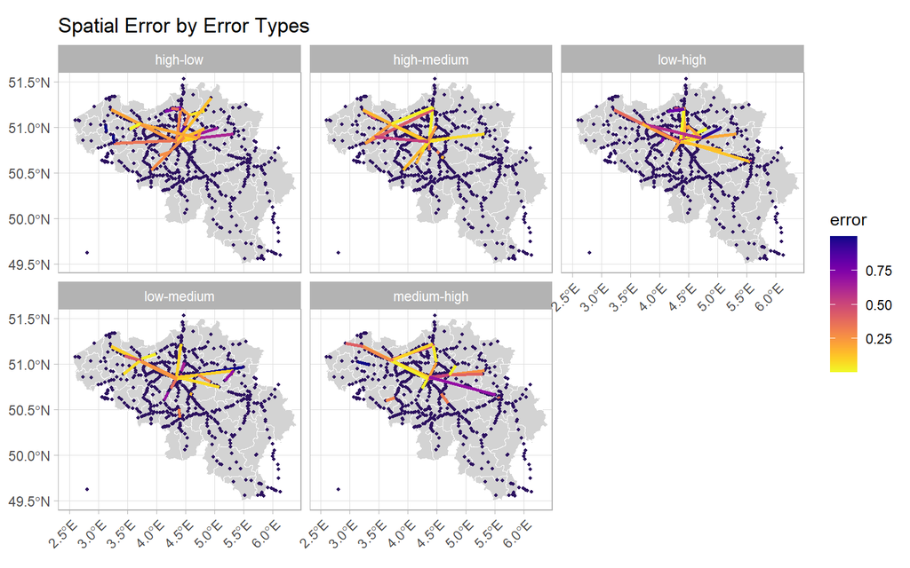

```r
ggplot(all_error)+
#geom_sf(data=rail,inherit.aes = FALSE, na.rm=T, col="black", lwd=0.2 ,alpha=0.2)+
geom_sf(data = belgium, fill = "lightgray", color = "white") +
geom_sf(data=stations, size = 0.7, inherit.aes = FALSE, col="#2c115f" )+
geom_sf(data=all_error, aes(color = error),lwd=1)+
    scale_colour_viridis(direction = -1, discrete = F, option = "C")+
     #facet_grid(rows = vars(type)) +
     facet_wrap(~type, ncol = 3)+
    ylim(min(49.5), max(51.5))+ #lat
    xlim(min(2.5), max(6.3))+
   labs(title="Spatial Error by Error Types")+
  theme_light()+
  theme(axis.text.x = element_text(angle = 45, hjust = 1))
```

### Temporal Errors

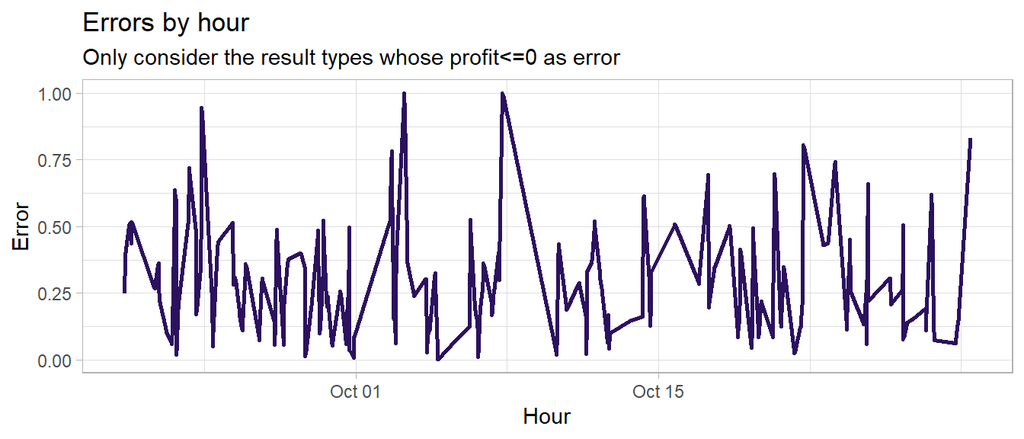

```r
all_error %>% filter(interval60>=as.Date("2016-09-20"))%>%
    ggplot(aes(interval60, error)) +
      geom_area(col = "#2c115f", fill = "transparent", size = 1) +
      labs(title = "Errors by hour",
           subtitle = "Only consider the result types whose profit<=0 as error",
             x="Hour",
             y="Error") +
  theme_light()
```

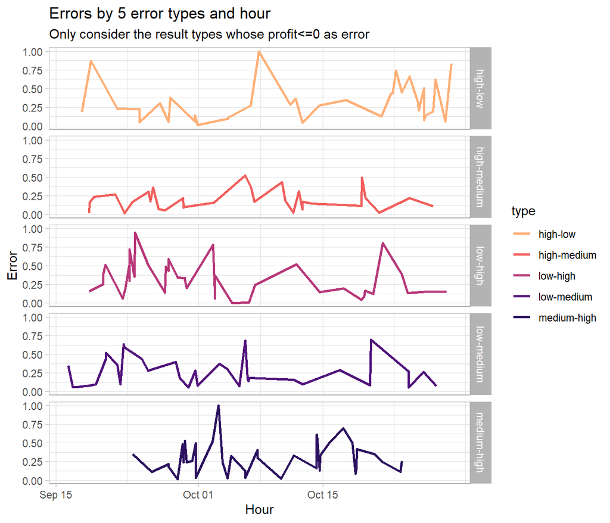

```r
all_error_df <- as.data.frame(all_error)
all_error_df %>% filter(interval60>=as.Date("2016-09-15"))%>%
    ggplot(aes(interval60, error, color=type)) +
      geom_line(lwd = 1) +
        scale_color_manual(values = palette5b) +
        #scale_color_viridis(discrete=TRUE, option = "C") +
        labs(title = "Errors by 5 error types and hour",
             subtitle = "Only consider the result types whose profit<=0 as error",
             x="Hour",
             y="Error") +
    #facet_wrap(~type, ncol=1) +
    facet_grid(rows = vars(type)) +
  theme_light()
```

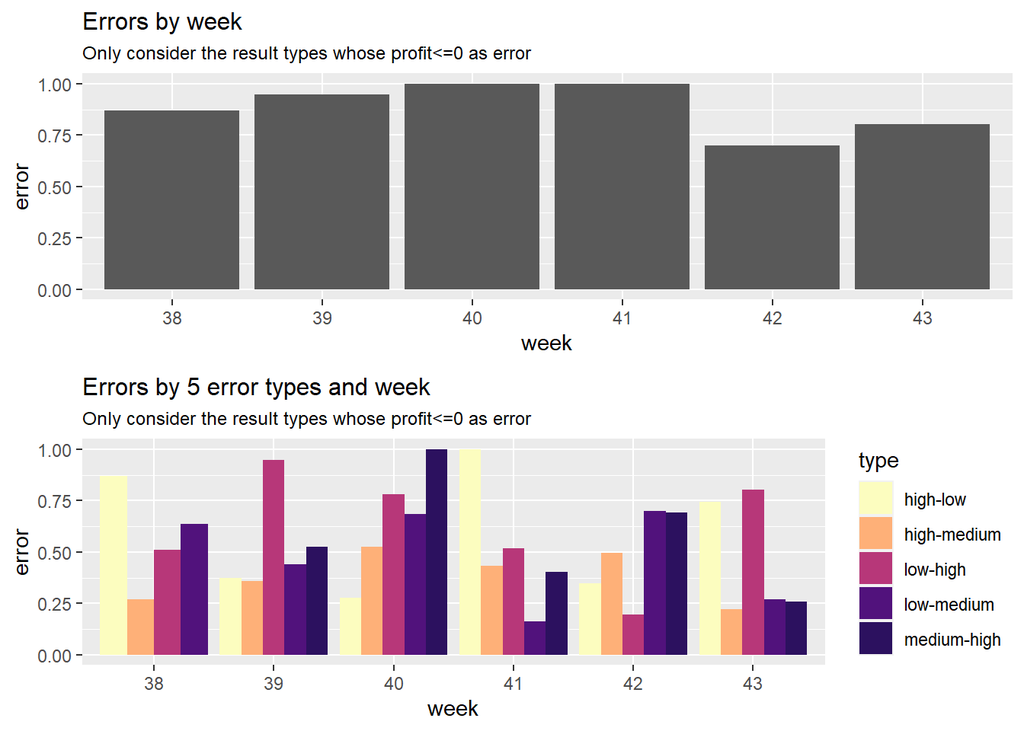

```r
grid.arrange(
  all_error_df %>%
  filter(week=="38"|week=="39"|week=="40"|week=="41"|week=="42"|week=="43")%>%
  ggplot(aes(x=week, y=error)) +
    geom_bar(position = "dodge", stat="identity") +
     scale_fill_manual(values = palette5) +
    labs(title = "Errors by week",
         subtitle = "Only consider the result types whose profit<=0 as error")+Theme2,
all_error_df %>%
  filter(week=="38"|week=="39"|week=="40"|week=="41"|week=="42"|week=="43")%>%
  dplyr::select(week, type, error) %>%
  gather(Variable, error, -type, -week) %>%
  ggplot(aes(x=week, y=error)) +
    geom_bar(aes(fill = type), position = "dodge", stat="identity") +
     scale_fill_manual(values = palette5) +
    labs(title = "Errors by 5 error types and week",
        subtitle = "Only consider the result types whose profit<=0 as error")+Theme2,
ncol=1)
```

# Recommendations

Model Recommendation: The model demonstrates balanced performance across various metrics, indicating reasonable predictive capabilities. This balance is crucial for ensuring that the model provides accurate predictions across different occupancy levels, supporting effective maintenance planning.

1. **Trade-offs:** For a maintenance planning application, the cost of false positives (unnecessary service restrictions) and false negatives (missed necessary maintenance) should be carefully considered. The trade-offs should align with the organization’s operational goals and priorities.
2. **Use Case Alignment:** The model aims to assist operators and transportation planners in better planning system maintenance operations. The moderate level of performance suggests that the model can be suitable for certain aspects of the use case. It’s important to assess whether the model’s strengths align with the specific needs of the NMBS/SNCB in optimizing scheduling around peak demand and minimizing service restrictions.
3. **Continuous Improvement:** Regular updates based on feedback, new data, and changing operational conditions can enhance the model’s effectiveness over time. This aligns with the goal of improving operational and financial performance.

The model appears to offer a reasonable level of performance for the NMBS/SNCB’s maintenance use case. Its balanced performance, consideration of trade-offs, alignment with the use case, and emphasis on continuous improvement contribute to its suitability. However, ongoing monitoring and refinement are essential to ensure that the model continues to meet the specific needs and priorities of the NMBS/SNCB in optimizing maintenance planning and scheduling.

Key Considerations for Implementation:

1. **Goodness of Fit:**
   - **Emphasize Accuracy over Immediacy:**
     - Fine-tune the model to prioritize accuracy even if it leads to a slight delay in predictions.
     - Adjust the model parameters to optimize for precision and recall, ensuring a balance that aligns with the importance of accurate predictions for maintenance planning.
2. **Nuanced Analysis & Profiling:**
   - **Customize Model for Stations and Lines:**
     - Conduct a thorough analysis of station-specific and line-specific characteristics.
     - Customize the model or train station/line-specific models if significant variations are observed.
     - Consider clustering stations or lines with similar characteristics for more targeted and precise predictions.
3. **Variable Enrichment & Layering:**
   - **Progressive Inclusion of Variables:**
     - Systematically include infrastructure and operational variables in the model, considering their impact on occupancy.
     - Start with core variables and progressively layer in additional features to identify their contribution to prediction accuracy.
     - Prioritize variables that have a significant impact on scheduling flexibility and maintenance priorities.
   - **Evaluate Scheduling Flexibility:**
     - Assess the impact of each variable on scheduling flexibility and prioritize those that provide actionable insights.
     - Consider variables related to track maintenance, train availability, and infrastructure condition to enhance the model’s understanding of scheduling constraints.
   - **Dynamic Adjustment of Variables:**
     - Implement a dynamic system that allows for the adjustment of variables based on real-time changes in infrastructure or operational conditions.
     - Regularly review and update the set of variables to ensure the model remains adaptive to the evolving transportation system.

These recommendations focus on aligning the model with the specific priorities of accuracy, nuanced analysis, and variable enrichment for the National Railway Company of Belgium (NMBS/SNCB). By customizing the model to the unique characteristics of stations and lines and progressively incorporating relevant variables, the model can provide more actionable insights for maintenance planning while maintaining a high level of accuracy.

```r
# # A. High Connectivity Stations
# station_buffer <- st_buffer(stations, dist = 300)  # 300 meters buffer
#
# # Add column to stations
# stations$lines_intersected <- lengths(st_intersects(station_buffer, line))
#
# # Bar chart
# ggplot(stations, aes(x = station_name, y = lines_intersected)) +
#   geom_bar(stat = "identity", fill = viridis(10)[5]) +
#   labs(x = "Station Name", y = "Count of Lines Intersected") +
#   theme_minimal()
#
# # B. High Connectivity Lines
# line_buffer <- st_buffer(line, dist = 100)  # 100 meters buffer
#
# # Add column to rail lines
# line$stations_intersected <- lengths(st_intersects(line_buffer, stations))
#
# # Bar chart
# ggplot(line, aes(x = line_name, y = stations_intersected)) +
#   geom_bar(stat = "identity", fill = viridis(10)[8]) +
#   labs(x = "Rail Line Name", y = "Count of Stations Intersected") +
#   theme_minimal()
#
# # C. Vulnerable Lines
# line$crossings_intersected <- lengths(st_intersects(line_buffer, crossing))
#
# # Bar chart
# ggplot(line, aes(x = line_name, y = crossings_intersected)) +
#   geom_bar(stat = "identity", fill = viridis(10)[3]) +
#   labs(x = "Rail Line Name", y = "Count of Crossings Intersected") +
#   theme_minimal()
#
# # Summary Representations
# # Overall Criticality Scatter Plot
# ggplot(line, aes(x = stations_intersected, y = crossings_intersected, color = lines_intersected)) +
#   geom_point() +
#   labs(x = "Count of Stations Intersected", y = "Count of Crossings Intersected") +
#   scale_color_viridis(name = "Count of Lines", option = "plasma") +
#   theme_minimal()
#
# # Overall Criticality Map
# line$criticality <- line$stations_intersected + line$crossings_intersected
#
# leaflet() %>%
#   addProviderTiles("Stamen.TonerLite") %>%
#   addCircles(data = stations, lng = ~geometry$longitude, lat = ~geometry$latitude,
#              color = viridis(10)[5], radius = 100, fillOpacity = 0.8) %>%
#   addPolylines(data = line, lng = ~geometry$longitude, lat = ~geometry$latitude,
#                color = viridis(10)[line$criticality]) %>%
#   addLegend(position = "bottomright", colors = viridis(10), title = "Criticality")
#
# # Combining Predictions & Criticality
# # Assuming you have a data frame called 'predictions' with columns: line_name, occupancy, criticality
#
# # Line plot for observed values
# ggplot(predictions, aes(x = criticality, y = ..count.., fill = occupancy)) +
#   geom_bar(stat = "count", position = "dodge") +
#   labs(x = "Criticality", y = "Frequency", fill = "Occupancy") +
#   facet_wrap(~occupancy) +
#   theme_minimal()
#
# # Line plot for predicted values
# ggplot(predictions, aes(x = criticality, y = ..count.., fill = occupancy)) +
#   geom_bar(stat = "count", position = "dodge") +
#   labs(x = "Criticality", y = "Frequency", fill = "Occupancy") +
#   facet_wrap(~occupancy) +
#   theme_minimal()
#
# # Maintenance Planning
# line$pred_num <- factor(predictions$occupancy, levels = c("low", "medium", "high"))
#
# # Select a rail line with high critical score
# selected_line <- line[which.max(line$criticality), ]
#
# # Plot predicted occupancy through time
# ggplot(predictions, aes(x = interval, y = pred_num)) +
#   geom_line() +
#   geom_point(data = filter(predictions, line_name == selected_line$line_name)) +
#   labs(x = "Time Interval", y = "Predicted Occupancy") +
#   theme_minimal()
```

# Data Sources:

https://www.kaggle.com/c/train-occupancy-prediction/discussion/27828#latest-156701

https://www.kaggle.com/c/train-occupancy-prediction/data

https://github.com/GillesVandewiele/KaggleTrainOccupancy/blob/master/line_info.csv

https://statbel.fgov.be/en/open-data/population-according-km2-grid

https://opendata.infrabel.be/explore/dataset/geoow/export/?disjunctive.fld_postcode_en_gemeente&disjunctive.type_lc

https://opendata.infrabel.be/explore/dataset/nationale-stiptheid-per-maand/information/?sort=maand&q.timerange.maand=maand:%5B2016-07-01+TO+2016-10-31%5D